# 13 Inférence Statistique: deux échantillons

- Montrer tout le code
- Cacher tout le code

Auteur

Affiliation

Daniel Coulombe

Institut des Sciences, Technologies et Études Avancées d’Haïti (ISTEAH)

Date

12/04/2024

Les procédures d’estimation et de test d’hypothèse impliquant un échantillon unique, étudiées dans les précédents chapitres, s’appliquent d’une manière conceptuellement identique lorsque deux échantillons sont comparés. Par exemple, là où il était question d’estimation d’une moyenne, il sera maintenant question d’estimation de la différence entre deux moyennes, impliquant une distribution d’échantillonnage d’une différence de moyennes et son erreur-standard. Ainsi, hormis quelques détails procéduraux, les mêmes concepts seront repris et appliqués.

## 13.1 Deux échantillons: indépendants ou dépendants?

Deux situations peuvent se présenter, lorsqu’on examine les différences susceptibles d’exister entre deux (ou plusieurs) échantillons:

- D’une part, les observations faites sur ces échantillons peuvent être indépendantes non seulement à l’intérieur de chacun des échantillons, mais également **entre** eux. En d’autres termes, les observations faites sur un échantillon ne nous apprennent absolument rien concernant les observations faites sur l’autre (ou les autres) échantillon(s). Les données sont indépendantes, n’ont aucun lien entre elles. Par exemple, lorsqu’on compare la performance d’une classe de mathématiques enseignée par le professeur X à celle d’une classe enseignée par le professeur Y, on peut considérer que nous sommes en présence d’échantillons indépendants.
- D’autre part, les observations faites sur un échantillon peuvent être liées, ou associées à celles faites sur un ou plusieurs autres échantillons. Ce lien se traduit par une corrélation, ou une association, entre les données: en connaissant une observation provenant du premier échantillon, on peut apprendre quelque chose sur l’observation qui lui est appariée dans le second échantillon. Par exemple, supposons un échantillon dont la performance des sujets dans une tâche donnée est évaluée **avant** et **après** une formation visant à améliorer leur efficacité. Dans un tel cas, ce sont les mêmes sujets que l’on évalue à deux (ou plusieurs) reprises, de sorte qu’une portion importante des facteurs susceptibles d’affecter la performance est *égalisée* entre les deux évaluations. En conséquence, les données sont corrélées, et l’analyse doit tenir compte de ce fait.

## 13.2 Estimation: deux échantillons indépendants

Les concepts définis et évoqués pour l’estimation de paramètres à partir d’un échantillon unique sont aisément applicables aux cas impliquant deux échantillons. On pourra s’intéresser, par exemple, à la différence pouvant exister entre les moyennes, les médianes, les variances, les proportions ou toute autre quantité définissant les caractéristiques de deux populations. Le résultat de l’opération sera un intervalle susceptible de capturer la différence entre les paramètres de deux populations, avec un certain niveau de confiance. On cherchera à répondre à des questions telles que:

**Quel intervalle pourrait capturer la différence entre la performance moyenne des garçons et celle des filles en mathématiques, au niveau fondamental?**

Pour obtenir cet intervalle, il sera nécessaire de spécifier la distribution d’échantillonnage des différences de moyennes. De manière à obtenir cette distribution, on devra tirer un échantillon de la première population (garçons) et calculer sa moyenne; on fera de même pour un échantillon tiré de la seconde population (filles), pour finalement obtenir la différence entre les deux moyennes échantillonnales. En répétant l’exercice un grand nombre de fois, on pourra obtenir la distribution d’échantillonnage essentielle au processus d’estimation. C’est l’approche que nous avons utilisée pour l’estimation d’un paramètre d’une seule population.

### 13.2.1 Intervalle de confiance pour groupes indépendants: Approche empirique

La fonction **RandUnif()** (Listing 13.1) permet de générer des ensembles de données aléatoires d’une population uniformément distribuée. Les bornes de la distribution sont sélectionnées aléatoirement à l’intérieur d’un intervalle donné. Les arguments de cette fonction sont:

**RandUnif(n=50, a=10, b=50)**  
* **n**: Nombre d’observations à générer  
* **a**: Scalaire indiquant la limite inférieure de la distribution  
* **b**: Scalaire indiquant la limite supérieure de la distribution

La fonction retourne une liste contenant le vecteur des nombres aléatoires générés, la limite inférieure et la limite supérieure de la distribution, au niveau de la population. Supposant que les résultats de la génération de données sont sauvegardées dans la liste **x1**, on pourra accéder aux données générées en utilisant **x1[[1]]**, à la limite inférieure au niveau de la population par **x1[[2]]** et à la limite supérieure par **x1[[3]]**.

Supposons deux échantillons indépendants de $n_1 =$ 25 et $n_2 =$ 35 observations, générées à l’aide de la fonction **RandUnif()**. Pour les besoins de la démonstration, les moyennes des populations d’où sont tirés les échantillons sont affichées. Mais rappelons que dans le monde réel, ces paramètres sont généralement inconnus et l’objectif d’une analyse est de les estimer.

```r
set.seed(1)

x1  <-  RandUnif(n=25,
                 a=10,
                 b=30)
mu1  <-  (x1[[3]] + x1[[2]])/2      # Mu 1
sig1 <- (x1[[3]]-x1[[2]])^2 / 12    # Sigma 1

x2  <-  RandUnif(n=35,
                 a=10,
                 b=30)
mu2  <-  (x2[[3]] + x2[[2]])/2      # Mu 2
sig2 <- (x2[[3]]-x2[[2]])^2 / 12    # Sigma 2
```

Les paramètres des populations d’où sont tirés les échantillons, de même que les statistiques correspondantes au niveau de ces derniers, sont les suivants:

**Statistiques**:  
* $\bar{X}_1 = 18.165 \qquad s_1 = 1.682$  
* $\bar{X}_2 = 23.104 \qquad s_2 = 2.627$  
* $\bar{X}_1 - \bar{X}_2 = -4.939$

Quelle pourrait être la différence entre les moyennes des populations d’où sont tirés ces échantillons (en supposant qu’on ignore leurs valeurs!)? On peut calculer la différence entre les moyennes observées, mais le résultat ne peut être considéré que comme un reflet de la différence réelle existant entre les moyennes des populations. Pour les échantillons étudiés, cette différence est égale à -4.939. La question est de savoir si cette différence est le reflèt d’une différence réelle au niveau de la population, et pour y répondre, il est nécessaire de connaître la distribution d’échantillonnage des différences de moyennes.

De manière à obtenir cette distribution, procédons par ré-échantillonnage. Le code R suivant fait le nécessaire et la distribution recherchée est affichée à la Figure 13.1. Cette procédure consiste à échantillonner **avec remise** les deux échantillons originaux un grand nombre de fois ($nrep = 10000$), en calculer les moyennes et leurs différences, pour ensuite en établir la distribution.

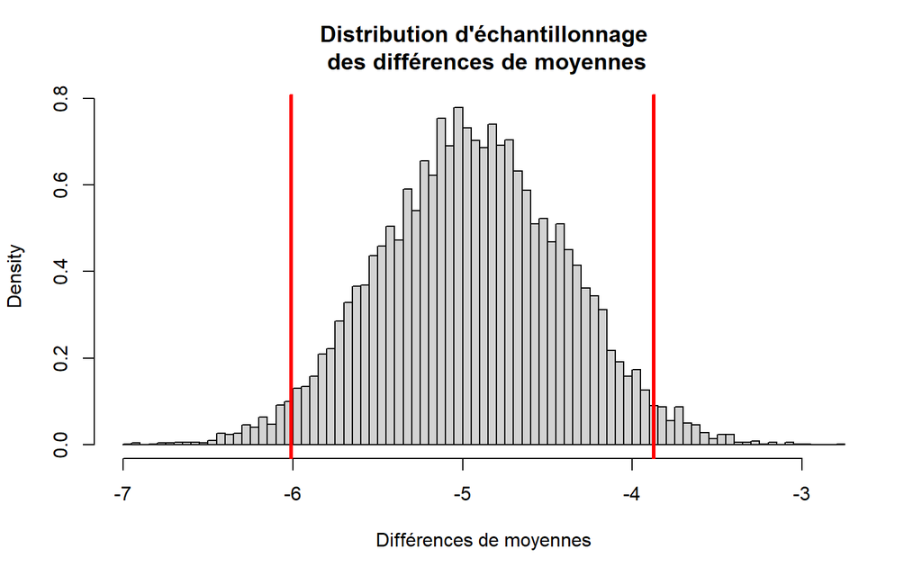

Figure 13.1: Distribution d’échantillonnage des différences de moyennes, obtenue par ré-échantillonnage (10,000 échantillons). Les lignes verticales rouges indiquent la position des percentiles 2.5 et 97.5, respectivement.

```r
nrep = 10000
moydiff <- replicate(nrep,
                    mean(sample(x1[[1]],
                                length(x1[[1]]),
                                replace=TRUE)) -
                    mean(sample(x2[[1]],
                                length(x2[[1]]),
                                replace=TRUE)))
hist(moydiff,
     main="Distribution d'échantillonnage\n des différences de moyennes",
     xlab="Différences de moyennes",
     freq=FALSE,
     breaks="FD")
lims = quantile(moydiff,c(0.025,0.975))
abline(v=lims,col="red",lwd=3)
```

En calculant les percentiles $P_{2.5}$ et $P_{97.5}$ de cette distribution, on obtient un intervalle de confiance (95%) pour différences de moyennes. Ainsi,

$C[$ -6.009 $\le \mu_1 - \mu_2 \le$ -3.875$]=95\%$

En répétant l’expérience un nombre infini de fois, 95% des intervalles de confiance pour différences de moyennes indépendantes captureraient la véritable différence des moyennes des populations ($\mu_1-\mu_2=-4.976$).

La fonction **boot.two.per()** de la librairie **wBoot** nous permet d’obtenir des résultats similaires, tel qu’illustré à la Figure 13.2. Les résultats diffèrent légèrement de ceux obtenus précédemment, puisque de nouveaux échantillons sont formés lors de l’application de la procédure. La fonction **print.boot.two()** produit l’impression des résultats sous une forme compacte.

```
#>
#>
#>  RESULTS OF PERCENTILE BOOTSTRAP FOR DIFF.MEAN
#>
#>     SUMMARY Pop.1 Pop.2 n.1 n.2 Statistic  Observed
#>  STATISTICS    X1    X2  25  35 diff.mean -4.939009
#>
#>  BOOTSTRAP Replications      Mean        SE    Bias Percent.bias
#>    SUMMARY        10000 -4.934473 0.5429673 0.00454       0.0919
#>
#>  HYPOTHESIS Null Alternative   P.value
#>        TEST    0   not-equal P < 0.001
#>
#>  CONFIDENCE Level      Type Confidence.interval
#>    INTERVAL   95% two-sided    (-5.987, -3.879)
```

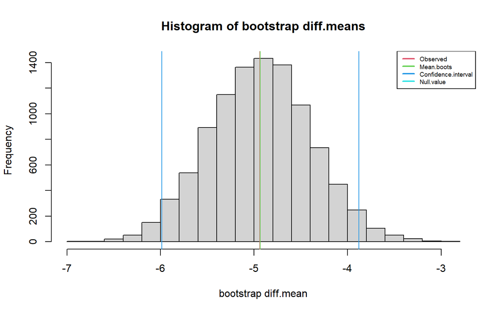

Figure 13.2: Distribution d’échantillonnage des différences de moyennes

```r
X1 <- x1[[1]]
X2 <- x2[[1]]
b.ind2 = wBoot::boot.two.per(X1, X2,
                             parameter = mean,
                             stacked = FALSE,
                             variable = NULL,
                             null.hyp = 0,
                             alternative = "two.sided",
                             conf.level = 0.95,
                             type = NULL,
                             R = 10000)
wBoot::print.boot.two(b.ind2)
```

On trouve une différence de $-4.939$ unités entre les deux moyennes. Sans surprise, la moyenne de la distribution de ré-échantillonnage est approximativement égale à cette différence ($\mu_{\bar{X}_1 - \bar{X}_2}=-4.934$). La probabilité d’observer une telle différence en supposant qu’au niveau de la population cette différence est nulle, est très faible: $p < 0.001$. De plus, une différence nulle ne fait pas partie de l’intervalle de confiance: [-5.987, -3.879]. Ces évidences renforcent l’idée que les moyennes pourraient être différentes au niveau de la population.

L’histogramme (Figure 13.2) indique la moyenne des différences entre les deux moyennes ( $\mu_{\bar{X}_1} - \mu_{\bar{X}_2}$ ) (ligne verticale verte) et l’intervalle de confiance (lignes verticales bleues). Notons que la moyenne de la distribution sera au moins approximativement égale à la différence des moyennes observée au niveau des échantillons. Pour $H_0:\mu_1-\mu_2=0$, si la valeur 0 se trouve à l’extérieur de l’intervalle de confiance, il y a évidence à l’effet que $H_0$ est fausse.

#### 13.2.1.1 Exemple 1: Différence de moyennes I

Estimons la différence qui pourrait exister entre la performance moyenne des hommes et des femmes au test de HabilCog, dans le département des Nippes. Pour les besoins de cette estimation, formons un échantillon de 35 hommes et de 40 femmes. Le code R suivant effectue cet échantillonnage.

```r
# Création des sous-populations
subpop = subset(HaitiPop,(DEPARTEMENT=="4"),c(GENRE,HabilCog))
subpopH = subset(subpop,GENRE=="M",HabilCog)
subpopF = subset(subpop,GENRE=="F",HabilCog)
# Création des échantillons
nH = 35
nF = 40
xechH = subpopH$HabilCog[sample(1:nrow(subpopH),
                                nH,
                                replace=FALSE)]
xechF = subpopF$HabilCog[sample(1:nrow(subpopF),
                                nF,
                                replace=FALSE)]
```

Les statistiques observées au niveau des échantillons sont les suivantes:

**Statistiques**:  
* $\bar{X}_1 = 100.383 \qquad s_1 = 12.408$  
* $\bar{X}_2 = 98.634 \qquad s_2 = 11.906$  
* $\bar{X}_1 - \bar{X}_2 = 1.749$

En appliquant une procédure de ré-échantillonnage ($k=100,000$) sur ces données, on obtient un ensemble de différences ($\bar{X}_1-\bar{X}_2$).

```r
nrep <- 100000
xbd <- replicate(nrep,
                 mean(sample(xechH,
                             length(xechH),
                             replace = TRUE))
                 -
                 mean(sample(xechF,
                             length(xechF),
                             replace = TRUE)))
```

```r
qtl <- quantile(xbd,
                c(0.025, 0.975))
```

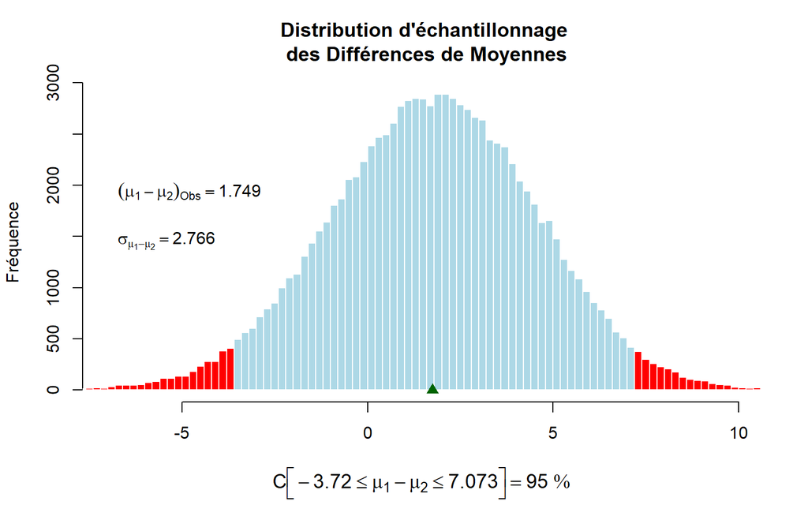

Figure 13.3: Distribution de ré-échantillonnage de la différence de deux moyennes indépendantes. L’intervalle de confiance (95%) est bordé par les zones rouges, aux extrémités de la distribution et affiché au bas du graphique. La différence observée entre les deux moyennes (estimation ponctuelle) est représentée par un triangle vert, sur l’axe horizontal.

Un résultat similaire, illustré à la Figure 13.4, pourrait s’obtenir à l’aide de la fonction **boot.two.per()** de la librairie **wBoot**:

```
#>
#>
#>  RESULTS OF PERCENTILE BOOTSTRAP FOR DIFF.MEAN
#>
#>     SUMMARY Pop.1 Pop.2 n.1 n.2 Statistic Observed
#>  STATISTICS xechH xechF  35  40 diff.mean 1.748699
#>
#>  BOOTSTRAP Replications    Mean       SE    Bias Percent.bias
#>    SUMMARY        1e+05 1.75166 2.784378 0.00296        0.169
#>
#>  CONFIDENCE Level      Type Confidence.interval
#>    INTERVAL   95% two-sided     (-3.794, 7.152)
```

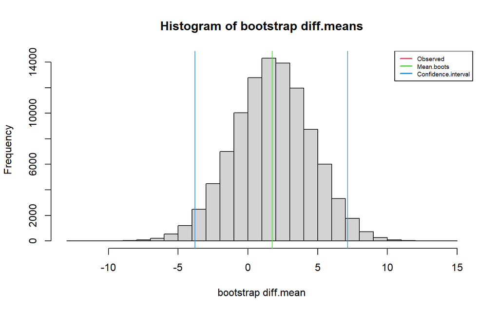

Figure 13.4: Distribution d’échantillonnage des différences de moyennes, pour l’exemple 1

```r
b.Diff = wBoot::boot.two.per(xechH,xechF,
                             mean,
                             conf.level=0.95,
                             R=100000,
                             stacked=FALSE)
b.Diff
```

Les résultats indiquent qu’il y a 95% des chances que la véritable différence entre les moyennes des Hommes et des Femmes au test d’Habileté Cognitive, au niveau de la population des Nippes, fasse partie des valeurs comprises entre les limites de l’intervalle (-3.794, 7.152) 19 fois sur 20 $[(1-\alpha)=0.95]$. Notons que la valeur ‘0’ (indiquant l’égalité entre les performances des hommes et des femmes) fait partie de cet intervalle. On ne pourrait donc pas conclure que les performances des hommes et des femmes sont différentes au niveau de la population, n’ayant pas d’évidence en ce sens.

#### 13.2.1.2 Exemple 2: Différence de proportions

Estimons maintenant la différence dans la proportion des adultes accordant leur confiance au Candidat A, dans les départements du Nord et de l’Ouest. On dispose d’un échantillon de 250 sujets dans le département du Nord, et de 325 sujets dans de département de l’Ouest. Le code R suivant procède à l’échantillonnage à partir des données générées par la fonction **HaitiPopGen()** (Listing 13.2), pour ensuite estimer la différence des proportions par ré-échantillonnage (100,000 échantillons).

```r
# Création des sous-populations
subpopN  <-  subset(HaitiPop,((DEPARTEMENT=="5")&(AGE>=18)), PrefPres)
subpopO  <-  subset(HaitiPop,((DEPARTEMENT=="8")&(AGE>=18)), PrefPres)

# Création des échantillons
nN  <-  250
nO  <-  325
xechN  <-  subpopN$PrefPres[sample(1:nrow(subpopN), nN, replace=FALSE)]==1
xechO  <-  subpopO$PrefPres[sample(1:nrow(subpopO), nO, replace=FALSE)]==1
```

Les statistiques observées au niveau des échantillons sont les suivantes, $p_{Nord}$ et $p_{Ouest}$ représentant les proportions des sujets favorisant le candidat A:

**Statistiques**:  
* $p_1 = 0.572$  
* $p_2 = 0.258$  
* $p_1 - p_2 = 0.314$

En appliquant une procédure de ré-échantillonnage ($k=100,000$) sur ces données, on obtient un ensemble de différences ($p_1-p_2$).

```r
nrep <- 100000
xbd <- replicate(nrep,
                 mean(sample(xechN,
                             length(xechN),
                             replace = TRUE)) -
                    mean(sample(xechO,
                             length(xechO),
                             replace = TRUE)))
```

La distribution de ces valeurs, illustrée à la Figure 13.5, semble gaussienne avec une estimation ponctuelle $\pi_1-\pi_2}=p_1-\pi_2=0.314$, et un écart-type $\sigma_{p_1-p_2}=0.04$. En déterminant les percentiles $P_{2.5}$ et $P_{97.5}$ de cette distribution, on trouve les limites de l’intervalle de confiance pour $(1-\alpha)=0.95$. Cet intervalle est indiqué au bas de la Figure 13.5:

```r
qtl <- quantile(xbd,
                c(0.025, 0.975))
```

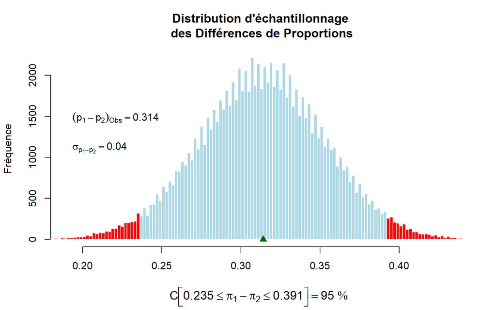

Figure 13.5: Distribution de ré-échantillonnage de la différence de deux proportions indépendantes. L’intervalle de confiance (95%) est bordé par les zones rouges, aux extrémités de la distribution et affiché au bas du graphique. La différence observée entre les deux proportions (estimation ponctuelle) est représentée par un triangle vert, sur l’axe horizontal.

Un résultat similaire, illustré à la Figure 13.6, pourrait s’obtenir à l’aide de la fonction **boot.two.per()** de la librairie **wBoot**:

```
#>
#>
#>  RESULTS OF PERCENTILE BOOTSTRAP FOR DIFF.MEAN
#>
#>     SUMMARY Pop.1 Pop.2 n.1 n.2 Statistic  Observed
#>  STATISTICS xechN xechO 250 325 diff.mean 0.3135385
#>
#>  BOOTSTRAP Replications      Mean         SE     Bias Percent.bias
#>    SUMMARY        1e+05 0.3135703 0.03965731 3.19e-05       0.0102
#>
#>  CONFIDENCE Level      Type Confidence.interval
#>    INTERVAL   95% two-sided    (0.2357, 0.3908)
```

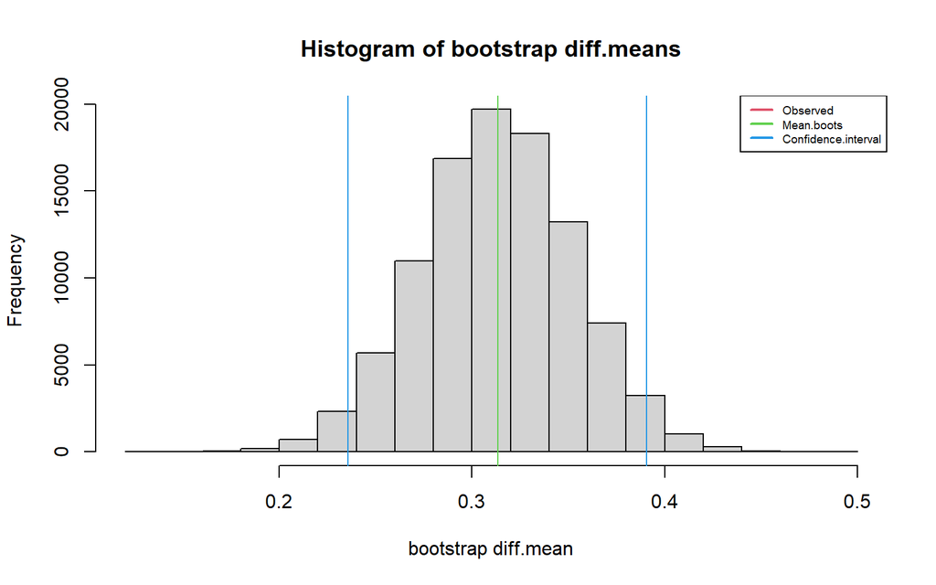

Figure 13.6: Distribution d’échantillonnage des proportions, pour l’exemple 2

```r
b.Diff  <-  boot.two.per(xechN,xechO,
                         mean,
                         conf.level=0.95,
                         R=100000,
                         stacked=FALSE)
print.boot.two(b.Diff)
```

Ici, on rapporte des moyennes et différences de moyennes, mais de fait, ces moyennes sont des proportions: rappelons que la moyenne de données binaires (0=contre, 1=pour) est une proportion.

Les résultats suggèrent qu’on est confiant à 95% que la véritable différence entre les proportions des individus favorisant le Candidat A aux prochaines élections présidentielles des départements du Nord et de l’Ouest se trouve parmi les valeurs comprises à l’intérieur de l’intervalle (0.2357, 0.3908) 19 fois sur 20 $[(1-\alpha)=0.95]$. Notons que la valeur ‘0’ (indiquant l’égalité des proportions entre les deux régions du pays) ne fait pas partie de cet intervalle. On peut donc conclure qu’il pourrait y avoir une différence entre les proportions d’électeurs favorisant le Candidat A, dans les deux départements. En effet, une différence nulle entre ces proportions est un événement improbable.

#### 13.2.1.3 Exemple 3: Différences de variances

Lorsqu’on doit estimer la différence entre deux variances, on serait immédiatement tenté d’adopter une stratégie analogue à l’estimation de la différence entre deux moyennes ou deux proportions. Cependant, contrairement aux moyennes ou aux proportions, qui sont des mesures de position pour lesquelles la différence simple est signifiante, une variance n’a pas d’unité de mesure et par conséquent ne peut être représentée sur un quelconque axe, et une simple différence entre deux variances $(\sigma_1^2-\sigma_2^2)$) ne signifie concrètement rien. Par contre, un rapport entre deux variances gagne en signifiance, et un tel rapport est permis, puisque le zéro absolu existe pour cette quantité (une variance peut être nulle, mais jamais négative). De plus, en s’assurant que la plus grande variance se trouve au numérateur, et la plus petite au dénominateur, on peut s’assurer au besoin, qu’une égalité de deux variances équivaudra à un rapport égal à 1.0.

Formons donc un rapport tel que formulé par l’Équation 13.1:

$$F=\frac{s_1^2}{s_2^2} \tag{13.1}$$

$F$ devient alors un indice de la différence qui peut exister entre les deux variances, et on peut aisément en établir la distribution d’échantillonnage.

Examinons la forme de la distribution de Fs calculés pour des paires d’échantillons de tailles $n_1 = 15$ et $n_2=25$, tirés d’une distribution normale avec $\mu=50$ et $\sigma=8$. Une telle distribution est illustrée à la Figure 13.7

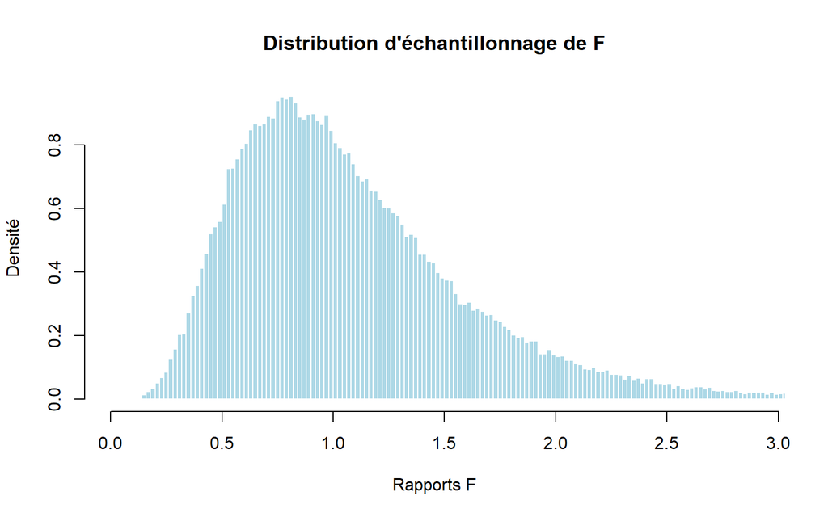

Figure 13.7: Distribution d’échantillonnage des rapports F

```r
nrep <- 100000
n1 <- 15
n2 <- 25
f <- replicate(nrep, {
  var_x1 <- var(rnorm(n1, 50, 8))
  var_x2 <- var(rnorm(n2, 50, 8))
  var_x1 / var_x2
})
```

On note immédiatement l’asymétrie positive de la distribution. On note également que 100% de la distribution se trouve sur la zone positive de l’axe horizontal, puisque le rapport entre deux quantités positives sera toujours lui-même positif. Et comme pour toutes les autres distributions que nous avons rencontrées jusqu’ici, on peut l’utiliser pour obtenir la probabilité de différents événements. Par exemple, la probabilité qu’un rapport F soit supérieur à 2 en tirant deux échantillons d’une population normalement distribuée avec $\mu=50$ et $\sigma=8$ serait:

```r
pr <- mean(f > 2)
cat("P(F > 2) = ", pr)
```

```
#> P(F > 2) =  0.06484
```

et la zone centrale comprenant 95% de la distribution serait:

```r
fc <- quantile(f, c(0.025, 0.975))
cat("P(", fc[1], "< F < ", fc[2], ") = 95%" )
```

```
#> P( 0.3600237 < F <  2.449744 ) = 95%
```

Cette distribution, comme la distribution normale, de Student ou du $\chi^2$, occupe une grande place dans la littérature statistique.

Pour fins d’illustration, considérons la différence qui pourrait exister entre la variabilité dans l’indice de criminalité (CRIMIDX) entre le département du Nord, et le département du Sud-Est. On tire un échantillon de 50 sujets âgés de 15 ans et plus du premier, et un échantillon de 60 du second. On calcule la variance des observations pour chacun des échantillons, et on établit le rapport F.

```r
# Spécification de la sous-population

subpopN = subset(HaitiPop,((DEPARTEMENT=="5")&(AGE>=15)),CRIMIDX)
subpopS = subset(HaitiPop,((DEPARTEMENT=="9")&(AGE>=15)),CRIMIDX)

# Création des échantillons

nN = 50
nS = 60
xechN = subpopN$CRIMIDX[sample(1:nrow(subpopN),nN,replace=FALSE)]
xechS = subpopS$CRIMIDX[sample(1:nrow(subpopS),nS,replace=FALSE)]
varN <- var(xechN)
varS <- var(xechS)
fech <- varN/varS
```

Les statistiques pertinentes sont les suivantes:

- $s_{Nord}^2 = 663.522$
- $s_{SudE}^2 = 437.797$
- $F=\frac{s_{Nord}^2}{s_{SudE}^2}=$ 1.516

Pour établir un intervalle de confiance pour le rapport $F=\frac{\sigma_1^2}{\sigma_2^2}$ à partir des variances observées pour les deux échantillons, le ré-échantillonnage est approprié. Le code R suivant se charge du travail, et la distribution résultante est affichée dans la Figure 13.8:

```r
nrep <- 100000
xbd <- replicate(nrep, {
  x1 <- sample(xechN, length(xechN), replace = TRUE)
  x2 <- sample(xechS, length(xechS), replace = TRUE)
  var(x1) / var(x2)
})

qtl <- quantile(xbd, c(0.025, 0.975))
```

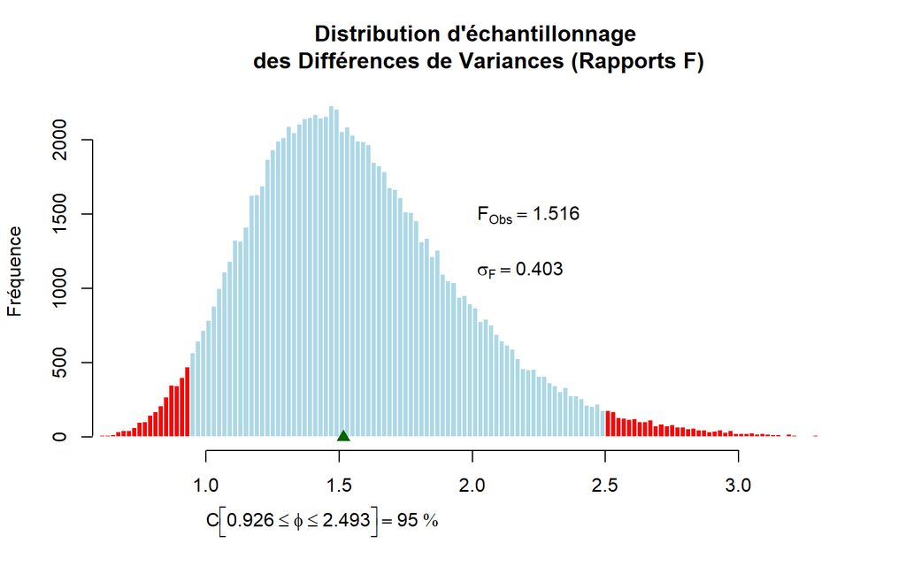

Figure 13.8: Distribution d’échantillonnage des rapports F quantifiant la dispersion de l’indice de criminalité dans les départements du Nord et du Sud-Est. L’intervalle de confiance (95%) correspond à la zone bleue, bordé par les valeurs indiquées sous le diagramme. Ces valeurs sont les 2.5e et 97.5e percentiles.

L’intervalle de confiance pour le rapport de variances obtenu se lit comme suit:

$$C[0.926\le \phi=\frac{\sigma_1^2}{\sigma_2^2}\le 2.493] = 95\%$$

Nous sommes confiants à 95% que l’intervalle obtenu capture le rapport des variances au niveau des deux populations. Notons également que la valeur F = 1.0 fait partie des valeurs probables de ce rapport: nous n’avons pas d’évidence à l’effet que les deux variances soient différentes l’une de l’autre, au niveau des populations.

```
#>
#>
#>  RESULTS OF PERCENTILE BOOTSTRAP FOR DIFF.VAR
#>
#>     SUMMARY Pop.1 Pop.2 n.1 n.2 Statistic Observed
#>  STATISTICS xechN xechS  50  60  diff.var 225.7245
#>
#>  BOOTSTRAP Replications     Mean       SE  Bias Percent.bias
#>    SUMMARY        1e+05 220.4614 130.0345 -5.26         2.33
#>
#>  CONFIDENCE Level      Type Confidence.interval
#>    INTERVAL   95% two-sided     (-38.37, 472.4)
```

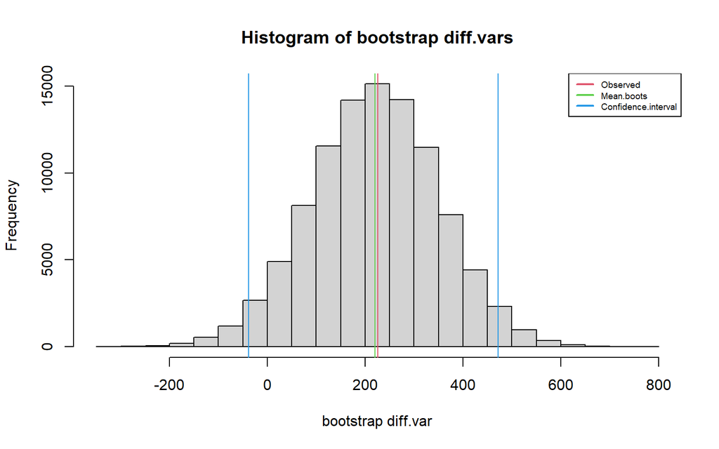

```r
Vr <-  function(x, y) {
  F <- var(x) / var(y)
  return(F)
}

b.Diff = wBoot::boot.two.per(xechN, xechS,
                             var,
                             conf.level=0.95,
                             R=100000,
                             stacked=FALSE)
wBoot::print.boot.two(b.Diff)
```

#### 13.2.1.4 Exemple 4: Différences de consensus

Estimons la différence dans le niveau de consensus concernant le projet d’une nouvelle Constitution au pays, au niveau des populations des régions nordiques (départements du Nord-Est, du Nord et du Nord-Ouest) et l’ensemble des départements du Centre et de l’Ouest. On dispose d’un échantillon de 250 sujets dans les départements du Nord, et de 325 sujets dans les départements du Centre et de l’Ouest. Le code R suivant permet de simuler cette situation, et la Figure 13.10 en illustre le résultat.

```r
# Fonction cons(), combinant table() et consensus()
cons = function(x){
  tbl = table(x)
  cns = agrmt::consensus(tbl)
  return(cns)
}

# Création des sous-populations
subpopN = subset(HaitiPop,
                 ((DEPARTEMENT %in% c("5","6","7"))&(AGE>=18)),
                 OpinConst)
subpopO = subset(HaitiPop,
                 ((DEPARTEMENT %in% c("2","8"))&(AGE>=18)),
                 OpinConst)

# Création des échantillons
nN = 250
nO = 325
xechN = subpopN$OpinConst[sample(1:nrow(subpopN),
                                 nN,
                                 replace=FALSE)]
xechO = subpopO$OpinConst[sample(1:nrow(subpopO),
                                 nO,
                                 replace=FALSE)]
paste("Consensus: (Nord)  = ", round(cons(xechN), 4), "      (Ouest) = ", round(cons(xechO), 4))
```

```
#> [1] "Consensus: (Nord)  =  0.6099       (Ouest) =  0.5887"
```

Par ré-échantillonnage, on obtient la distribution d’échantillonnage à l’aide de la fonction **boot.two.per()**, de la librairie **wBoot**, présentée au chapitre Chapitre 11:

```
#>
#>
#>  RESULTS OF PERCENTILE BOOTSTRAP FOR DIFF.CONS
#>
#>     SUMMARY Pop.1 Pop.2 n.1 n.2 Statistic   Observed
#>  STATISTICS xechN xechO 250 325 diff.cons 0.02122823
#>
#>  BOOTSTRAP Replications       Mean         SE     Bias Percent.bias
#>    SUMMARY        1e+05 0.02199342 0.03529146 0.000765          3.6
#>
#>  CONFIDENCE Level      Type Confidence.interval
#>    INTERVAL   95% two-sided (-0.04774, 0.09055)
```

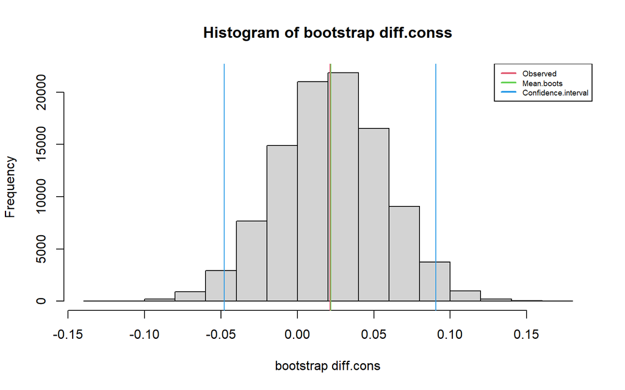

Figure 13.10: Distribution d’échantillonnage du consensus

```r
b.Diff = wBoot::boot.two.per(xechN,xechO,
                             cons,
                             conf.level=0.95,
                             R=100000,
                             stacked=FALSE)
wBoot::print.boot.two(b.Diff)
```

### 13.2.2 Intervalle de confiance pour groupes indépendants: Approche analytique

On a pu constater visuellement que la distribution d’échantillonnage des différences de moyennes était au moins approximativement normale. Comme on a pu le faire lorsqu’on devait estimer une seule moyenne sous réserve du respect de certains postulats, il est possible d’aborder le problème de manière analytique, en considérant que la distribution normale est un modèle adéquat pour l’obtention des probabilités requises pour le processus d’estimation.

La distribution d’échantillonnage des différences de moyennes est caractérisée par:

- une distribution gaussienne, à la condition que les populations d’où sont tirés les échantillons soient normales
- une moyenne qui à la limite, pour un nombre infini de paires d’échantillons, est égale à la différence entre les moyennes des populations ($\mu_1-\mu_2$)
- une erreur-standard définie par l’Équation 13.2:

$$\sigma_{\bar X_1-\bar X_2}=\sqrt{\frac{\sigma_1^2}{n_1}+\frac{\sigma_2^2}{n_2}}=\sqrt{\sigma_{\bar X_1}^2+\sigma_{\bar X_2}^2}
\tag{13.2}$$

Ces trois caractéristiques connues, la définition d’un intervalle de confiance pour différences de moyennes suit la même démarche que dans les cas étudiés jusqu’à maintenant, impliquant une statistique unique. L’Équation 13.3 en formalise l’opération.

$$C[(\bar X_1-\bar X_2)-z_{(1-\alpha/2)}\sigma_{\bar X_1-\bar X_2}\le (\mu_1-\mu_2) \le (\bar X_1-\bar X_2)+z_{(1-\alpha/2)}\sigma_{\bar X_1-\bar X_2}]=100\times(1-\alpha)\%
\tag{13.3}$$

La formule s’allonge un peu, mais elle ne contient rien de nouveau, conceptuellement. La quantité $(\bar X_1-\bar X_2)$ est la statistique échantillonnale à partir de laquelle on tente d’estimer le paramètre correspondant: $(\mu_1-\mu_2)$; la quantité $z_{(1-\alpha/2)}$ est le percentile sous la distribution normale correspondant au niveau de confiance désiré. La marge d’erreur, on peut le deviner, est défini par l’Équation 13.4:

$$ME=z_{(1-\alpha/2)}\sigma_{\bar X_1-\bar X_2}
\tag{13.4}$$

#### 13.2.2.1 Exemple 5: Échantillons de grandes tailles (ou $\sigma_1$ et $\sigma_2$ connus)

Examinons la différence qui pourrait exister entre l’indice de criminalité moyen chez les hommes vivant en Artibonite et ceux vivant dans le département du Sud. On peut disposer d’un échantillon de 50 sujets en Artibonite, et de 45 sujets dans le département du Sud. Le code R suivant produit des deux échantillons requis.

```r
set.seed(1234534)
# Création des sous-populations
subpopA = subset(HaitiPop,((DEPARTEMENT=="2")&(GENRE=="M")&(AGE>=15)),CRIMIDX)
subpopS = subset(HaitiPop,((DEPARTEMENT=="10")&(GENRE=="M")&(AGE>=15)),CRIMIDX)

# Création des échantillons
nA = 50
nS = 45
xechA = subpopA$CRIMIDX[sample(1:nrow(subpopA),
                               nA,
                               replace=FALSE)]
xechS = subpopS$CRIMIDX[sample(1:nrow(subpopS),
                               nS,
                               replace=FALSE)]
```

Pour résoudre ce problème, nous disposons des moyennes observées pour chaque échantillon, et les écarts-types de chaque populations:

Description des données échantillonnales

| Département | Moyenne | Écart-type (Population) | Écart-type (Échant.) | n |
| --- | --- | --- | --- | --- |
| Artibonite | 98.72 | 20.27 | 21.30 | 50 |
| Sud | 106.51 | 20.20 | 20.46 | 45 |

Pour un niveau de confiance de $100(1-\alpha)=95\%$, le percentile requis est $z=1.96$. On obtient donc:

$$\begin{align}
C[(\bar X_1-\bar X_2)-z_{(1-\alpha/2)}\sigma_{\bar X_1-\bar X_2}\le (\mu_1-\mu_2) \le (\bar X_1-\bar X_2)+z_{(1-\alpha/2)}\sigma_{\bar X_1-\bar X_2}]=100\times(1-\alpha)\% \\
C[(98.721-106.507)-1.96(4.157)\le (\mu_1-\mu_2) \le (98.721-106.507)+1.96(4.157)] &=95\% \\
C[-7.786-1.96(4.157)\le (\mu_1-\mu_2) \le -7.786+1.96(4.157)] &=95\% \\
C[-15.934 \le (\mu_1-\mu_2) \le 0.362] &=95\%
\end{align}$$

On note qu’une différence nulle entre les moyennes est un événement probable, se trouvant à l’intérieur de cet intervalle.

#### 13.2.2.2 Exemple 6: Échantillons de petites tailles et $\sigma_1$ et $\sigma_2$ inconnus

À l’instar de la procédure concernant une moyenne unique obtenue d’un échantillon de faible taille, il conviendra de considérer la distribution de Student afin de corriger pour la difficulté d’estimer la variabilité de la population dans ces conditions. Mais nous ajouterons un détail important:

- Considérant que nous sommes en présence de deux échantillons de petite taille;
- Considérant que l’estimation de la variabilité de chacune des populations à partir de ces échantillons est difficile;
- Il conviendra de combiner les deux échantillons de manière à obtenir une meilleure estimation de la variabilité des populations, que l’on considère commune à ces dernières.

En présence de deux échantillons, potentiellement de petites tailles, tirés de populations dont les écarts-types sont inconnus, on obtiendra une variance combinée telle que définie par l’Équation 13.5.

$$s_C^2=\frac{(n_1-1)s_1^2+(n_2-1)s_2^2}{n_1+n_2-2}=\frac{\sum\limits_{i=1}^{n_1}(X_{i1}-\bar X_1)^2+\sum\limits_{j=1}^{n_2} (X_{j2}-\bar X_2)^2}{n_1+n_2-2}
\tag{13.5}$$

$$s_C^2=\frac{(50-1)21.297^2+(45-1)20.463^2}{93}=437.079$$

On utilise ensuite cette estimation de la variance dans le calcul de l’erreur-standard des différences de moyennes:

$$s_{\bar X_1-\bar X_2}=\sqrt{\frac{s_C^2}{n_1}+\frac{s_C^2}{n_2}}= \sqrt{\frac{437.079}{50}+\frac{437.079}{45}}=4.296$$

Le nombre de degrés de liberté dans la présente situation est égal à:

$$dl=(n_1-1)+(n_2-1)=n_1+n_2-2=50+45-2=93$$

et le percentile correspondant, sous la distribution de Student est:

```r
tc <- round(qt(0.975, dl), 3)
cat("t(97.5) = ", tc)
```

```
#> t(97.5) =  1.986
```

$$C[(\bar X_1-\bar X_2)-t_{(dl;1-\alpha/2)}s_{\bar X_1-\bar X_2} \le \mu_1-\mu_2 \le (\bar X_1-\bar X_2)+t_{(dl;1-\alpha/2)} s_{\bar X_1-\bar X_2}]=100(1-\alpha)\%$$

$$C[(98.721-106.507)-1.986(4.296) \le \mu_1-\mu_2 \le (98.721-106.507)+1.986(4.296)]=95\%$$

$$C[-7.786-1.986(4.296) \le \mu_1-\mu_2 \le -7.786+1.986(4.296)]=95\%$$

$$C[-16.317 \le \mu_1-\mu_2 \le 0.745]=95\%$$

#### 13.2.2.3 Exemple 7: Estimation de différences de variances

La **distribution de Fisher-Snedecor**, ou **distribution F**, est la distribution de probabilité appropriée pour l’examen des rapports F. Elle est asymétrique positive, tel que requis pour la présente situation. Puisque les deux variances composant le rapport F sont des variables aléatoires lorsque calculées pour un grand nombre d’échantillons, un nombre de degrés de liberté sera associé à chacune d’elles:

- $dl_{num}=n_1-1$
- $dl_{dén}=n_2-1$

La distribution F est complètement spécifiée par ces deux quantités, comme on peut le constater en examinant sa fonction de densité (Équation 13.6:

$$f(X;dl_1, dl_2)=\frac{\sqrt{\frac{(dl_1 X)^{dl_1}dl_2^{dl_2}}{(dl_1 X+dl_2)^{dl_1+dl_2}}}}{X\textbf{B}\left (\frac{dl_1}{2},\frac{dl_2}{2}\right)}
\tag{13.6}$$

La moyenne de cette distribution est définie par l’Équation 13.7:

$$\mu_{F; dl_1, dl_2}=\frac{dl_2}{dl_2-2}
\tag{13.7}$$

et sa variance par l’Équation 13.8:

$$\sigma_{F;dl_1,dl_2}^2=\frac{2 dl_2^2(dl_1+dl_2-2)}{dl_1(dl_2-2)^2(dl_2-4)}
\tag{13.8}$$

Ces équations ne sont présentées ici que pour illustrer le fait que les deux seuls paramètres de cette distribution sont les nombres de degrés de liberté pour le numérateur et le dénominateur du rapport F. Pour toute combinaison de ces deux paramètres, une distribution F distincte existe. La Figure 13.11 en présente quelques-unes, pour $dl_{dénom}=20$:

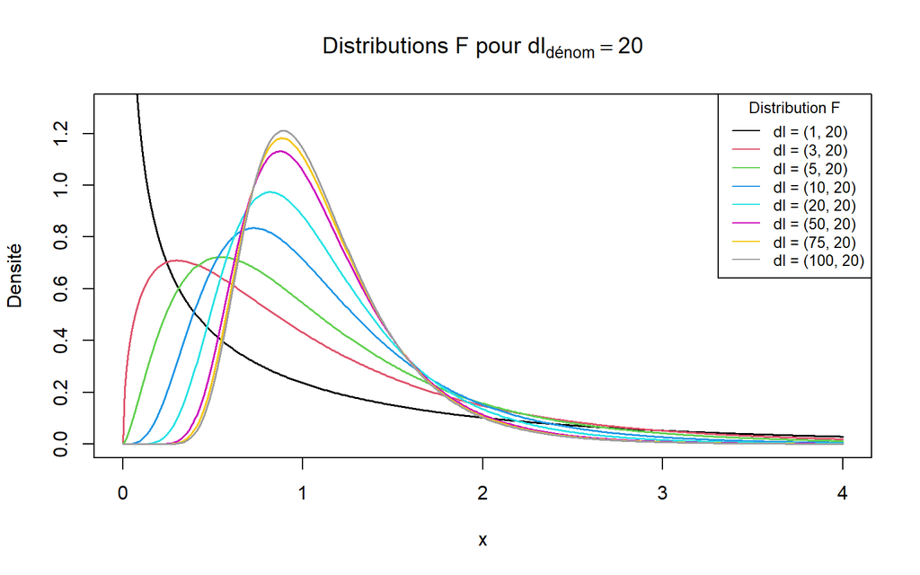

Figure 13.11: Famille de distributions F. Le nombre de degrés de liberté au dénominateur est fixé à 20. Une distribution est illustrée pour un sous-ensemble des nombres de degrés de liberté possibles pour le numérateur.

Sous R, les fonctions suivantes permettent d’effectuer les calculs de probabilité relatifs à cette distribution:

- **df(x, df1, df2)**: Fonction de densité
- **pf(q, df1, df2, lower.tail = TRUE)**: Fonction de probabilité cumulative
- **qf(p, df1, df2, lower.tail = TRUE)**: Fonction quantile
- **rf(n, df1, df2)**: Génération de nombres aléatoires

Par exemple, quelle est la probabilité d’obtenir un rapport F supérieur à 1.5, si $dl_1=5$ et $dl_2=30$?

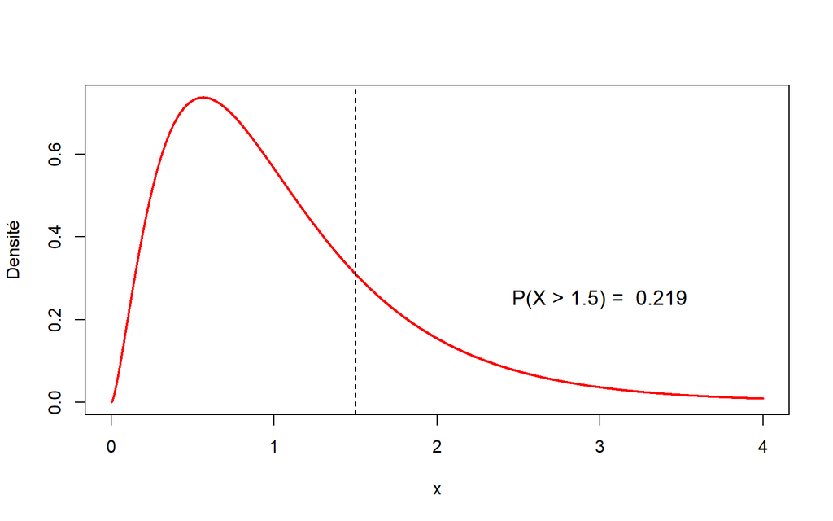

À ce stade, nous disposons de tout ce qui est nécessaire pour construire un intervalle de confiance pour un rapport F. Cet intervalle est défini formellement par l’Équation 13.9.

$$C \left [F_{(\alpha/2;dl_{num},dl_{dén})} \left( \frac{s_1^2}{s_2^2} \right ) \le \left (\frac{\sigma_1^2}{\sigma_2^2} \right ) \le F_{(1-\alpha/2;dl_{num},dl_{dén})} \left( \frac{s_1^2}{s_2^2} \right ) \right]=100(1-\alpha)\%
\tag{13.9}$$

Les quantités $F_{(\alpha/2;dl_{num},dl_{dén})}$ et $F_{(1-\alpha/2;dl_{num},dl_{dén})}$ sont les percentiles de la distribution de F correspondant au niveau de confiance désiré.

```r
subpopN = subset(HaitiPop,((DEPARTEMENT=="5")&(AGE>=15)),CRIMIDX)
subpopS = subset(HaitiPop,((DEPARTEMENT=="9")&(AGE>=15)),CRIMIDX)

nN = 50
nS = 60
xechN = subpopN$CRIMIDX[sample(1:nrow(subpopN),nN,replace=FALSE)]
xechS = subpopS$CRIMIDX[sample(1:nrow(subpopS),nS,replace=FALSE)]
```

Table 13.1: Description des données échantillonnales

[output not shown]

En utilisant un niveau de confiance de $(1-\alpha)=0.95$, les percentiles $P_{2.5}$ et $P_{97.5}$ de la distribution F pour $dl_{num}=50-1=49$, et $dl_{dén}=60-1=59$ sont:

```r
intc <- qf(c(0.025, 0.975), 49, 59)
cat("Percentiles P(2.5) et P(97.5)= ", intc)
```

```
#> Percentiles P(2.5) et P(97.5)=  0.5778867 1.706867
```

et la Figure 13.12 en fournit une illustration.

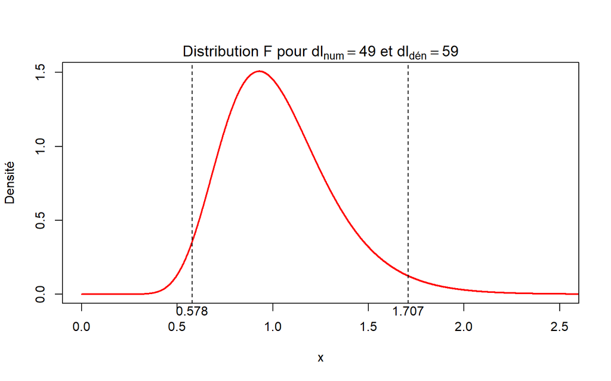

Figure 13.12: Distribution F pour $dl_{num}=49$ et $dl_{dén}=59$

L’intervalle de confiance pour le rapport F est donc:

$$\begin{align}
C \left [F_{(\alpha/2;dl_{num},dl_{dén})} \left( \frac{s_1^2}{s_2^2} \right ) \le \left (\frac{\sigma_1^2}{\sigma_2^2} \right ) \le F_{(1-\alpha/2;dl_{num},dl_{dén})} \left( \frac{s_1^2}{s_2^2} \right ) \right]=100(1-\alpha)\% \\
C \left [0.578 \left( \frac{332.317}{548.385} \right ) \le \left (\frac{\sigma_1^2}{\sigma_2^2} \right ) \le 1.707 \left( \frac{332.317}{548.385} \right ) \right ] = 95\% \\
C \left [ 0.35 \le \left (\frac{\sigma_1^2}{\sigma_2^2} \right ) \le 1.034 \right ] = 95\%
\end{align}$$

Il y a 95% des chances que le rapport des variances des populations soit une des valeurs délimitées par l’intervalle obtenu.

#### 13.2.2.4 Exemple 8: Estimation de différences de proportions

Un intervalle de confiance pour une différence de proportions, on le devine, se construit à partir d’une distribution d’échantillonnage de différences de proportions. Une telle distribution sera caractérisée par:

- une forme gaussienne
- une moyenne ($\mu_{p_1-p_2}$) égale à la différence des proportions au niveau des populations ($\pi_1-\pi_2$)
- un erreur-standard défini par l’Équation 13.10:

$$s_{p_1-p_2}=\sqrt{\frac{p_1(1-p_1)}{n_1}+\frac{p_2(1-p_2)}{n_2}}
\tag{13.10}$$

L’intervalle de confiance d’une différence de proportions se construit à l’instar des autres intervalles de confiance étudiés jusqu’ici et prend la forme affichée à l’Équation 13.11:

$$C \left [ (p_1-p_2)-z_{1-\alpha}s_{p_1-p_2} \le \pi_1-\pi_2 \le (p_1-p_2)+z_{1-\alpha}s_{p_1-p_2}\right ]=100(1-\alpha)\%
\tag{13.11}$$

```r
subpopN = subset(HaitiPop,((DEPARTEMENT=="5")&(AGE>=18)),PrefPres)
subpopO = subset(HaitiPop,((DEPARTEMENT=="8")&(AGE>=18)),PrefPres)

nN = 250
nO = 325
xechN = subpopN$PrefPres[sample(1:nrow(subpopN),nN,replace=FALSE)]==1
xechO = subpopO$PrefPres[sample(1:nrow(subpopO),nO,replace=FALSE)]==1

p1 <- round(mean(xechN), 3)
p2 <- round(mean(xechO), 3)

paste("Proportion: Nord  = ", p1, "    Ouest = ", p2)
```

```
#> [1] "Proportion: Nord  =  0.568     Ouest =  0.283"
```

À partir de ces données, on trouve une erreur-standard:

$$s_{p_1-p_2}=\sqrt{\frac{ p1(1-p1)}{250}+\frac {p2(1-p2)}{325}}=\sqrt{\frac{0.568(1-0.568)}{250}+\frac{0.283(1-0.568)}{325}}=0.04$$
et pour un niveau de confiance de 95%, l’intervalle de confiance est défini par:

$$\begin{align}
C \left [ (p_1-p_2)-z_{1-\alpha}s_{p_1-p_2} \le \pi_1-\pi_2 \le (p_1-p_2)+z_{1-\alpha}s_{p_1-p_2}\right ]&=100(1-\alpha)\%\\
C \left [ (0.568)-0.283))-1.96(0.04) \le \pi_1-\pi_2 \le (0.568)-0.283))+1.96(0.04)\right ]&=95\%\\
C \left [ 0.2066 \le \pi_1-\pi_2 \le 0.3634\right ]&=95\%
\end{align}$$

On peut être confiant à 95% que la différence de proportions au niveau de la population est capturée par cet intervalle.

## 13.3 Test d’hypothèse pour groupes indépendants: Approche empirique

Au Chapitre 11, le ré-échantillonnage était le véhicule privilégié pour une approche empirique à la vérification d’hypothèses. Cette méthode permettait de générer la distribution de ré-échantillonnage d’une statistique donnée, et d’en spécifier l’erreur-standard. La moyenne d’une telle distribution correspond à l’estimateur considéré. Armé de ces informations, on a pu mettre en oeuvre les inférences statistiques appropriées pour les situations impliquant un échantillon unique.

Il est toujours possible d’utiliser le ré-échantillonnage lorsqu’une analyse implique la vérification d’hypothèse concernant deux populations indépendantes. Il suffit de ré-échantillonner séparément chacun des échantillons et de calculer la différence entre les deux statistiques observées, répétant le processus un grand nombre de fois. La moyenne de la distribution des différences est égale à la différence entre les statistiques observées pour les deux échantillons. Cependant, il existe une alternative à cette procédure, généralement préférée: le **test de permutations**.

### 13.3.1 Test de permutations

On utilise le test de permutations pour générer une distribution sous $H_0$ pour une statistique mesurant une association entre deux variables, ou la différence entre les statistiques observées pour deux (ou plusieurs) groupes.

Le concept est simple:

- La répartition des observations dans les deux groupes n’est qu’une parmi $(n_1+n_2)!$ permutations possibles.
- En obtenant la statistique échantillonnale d’intérêt pour un grand nombre de permutations des mêmes données, on obtient la distribution d’échantillonnage de cette statistique
- Dès lors, on peut évaluer la probabilité d’obtenir la statistique initiale ou des valeurs plus extrêmes.

Essentiellement, la question posée est **combien parmi toutes les permutations qu’il est possible de former pour $n$ objets pris $n$ à la fois produiraient le résultat observé ou un résultat plus extrême?**

Pour illustrer, considérons l’expérience suivante. On dispose de 10 observations formant deux groupes. Le premier groupe obtient les scores 1 à 5, et le second groupe obtient les scores 6-10. La différence entre les deux moyennes est égale à -5. On procède au test de la manière suivante, supposant que la différence entre les deux moyennes est la statistique d’intérêt:

- On génère toutes les permutations possibles (#P = n! = 10! = 3,628,800), répartissant chacune d’elles en 2 groupes (groupe 1 = observations 1-5; groupe 2 = observations 6-10).
- Pour chaque permutation, on calcule la différence entre leurs moyennes respectives.
- On obtient ainsi toutes les différences de moyennes qu’il est possible d’obtenir pour les données disponiles: elles forme la distribution d’échantillonnage des différences de moyennes.
- La moyenne de cette distribution est nulle, et son écart-type est l’erreur-standard des différences de moyennes.

Le code R suivant est une illustration de la procédure. On y utilise la fonction **permutations()** de la librairie **gtools**:

```r
perm <- gtools::permutations(10, 10, c(1:10)) # Permutations des nombres de 1 à 10

mdif <- apply(perm,                           # Pour chaque permutation...
              MARGIN = 1,
              function(x) mean(x[1:5]) - mean(x[6:10])) # calcul de la différence entre les moyennes

mtot <- mean(mdif)                    # Moyenne de la distribution des différences de moyennes
stot <- sd(mdif)                      # Erreur-standard de la distribution des différences de moyennes
sktot <- moments::skewness(mdif)      # Indice de symétrie
kutot <- moments::kurtosis(mdif)      # Indice de voussure
```

$$\mu_{\Delta_{\bar{X}}}=-1.1748392\times 10^{-20} \qquad \sigma_{\Delta_{\bar{X}}}=1.9149 \qquad Sk = 0 \qquad Ku = 2.6291$$

La Figure 13.13 représente la distribution des différences observées entre les moyennes des deux groupes ($\Delta_{\bar{X}}$).

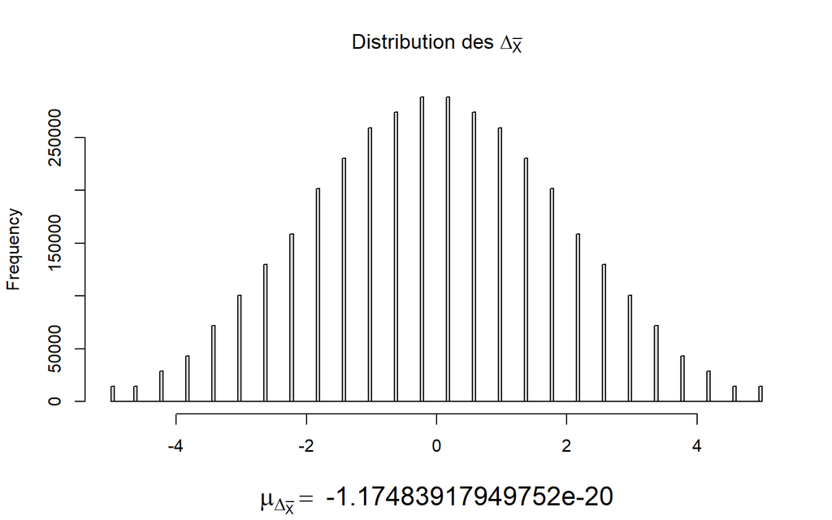

Figure 13.13: Distribution des différences de moyennes obtenues pour l’ensemble des permutations formées des nombres de 1 à 10, les 5 premiers et les 5 derniers formant deux groupes indépendants.

On note que la moyenne des différences observées entre les moyennes ($\mu_{\Delta_{\bar{X}}}$) est essentiellement nulle ($-1.17 \times 10^{-20})$. On note également que la distribution est parfaitement symétrique, et mésokurtique (ou très légèrement platykurtique). La distribution normale pourrait servir de modèle dans ce cas. De cette distribution, on peut déterminer la probabilité que dans ces conditions, une permutation produise une différence supérieure à 3, par exemple. On trouve alors:

```r
pr <- mean(mdif > 3)
```

$$p(\Delta_{\bar{X}} > 3) = 0.04762$$

En utilisant la distribution normale comme modèle, on trouve:

```r
pr2 <- pnorm(3, mean = mtot, sd = stot, lower.tail = FALSE)
```

$$p(\Delta_{\bar{X}} > 3) = 0.05859$$

Ces deux probabilités sont similaires.

Dans un contexte plus réaliste, la taille des échantillons utilisés dans une recherche quantitative implique un nombre de permutations astronomiques. Dans un tel cas, on ne pourra former qu’un certain nombre de permutations. Toutefois, si ce nombre est suffisamment élevé, on pourra obtenir une distribution suffisamment précise pour les besoins de l’analyse.

Reprenons la même expérience, mais en limitant à 100,000 le nombre de permutations générées. Ces permutations sont sélectionnées au hasard, parmi le $n!$ obtenues précédemment.

```r
subperm <- perm[sample(1:nrow(perm), 100000), ]

mdif <- apply(subperm, 1, function(x) mean(x[1:5]) - mean(x[6:10]))

msel <- mean(mdif)
ssel <- sd(mdif, na.rm = TRUE)
sksel <- moments::skewness(mdif)
kusel <- moments::kurtosis(mdif)
```

$$\mu_{\Delta_{\bar{X}}}=0.00186 \qquad \sigma_{\Delta_{\bar{X}}}=1.9133 \qquad Sk = -0.0048119 \qquad Ku = 2.637$$

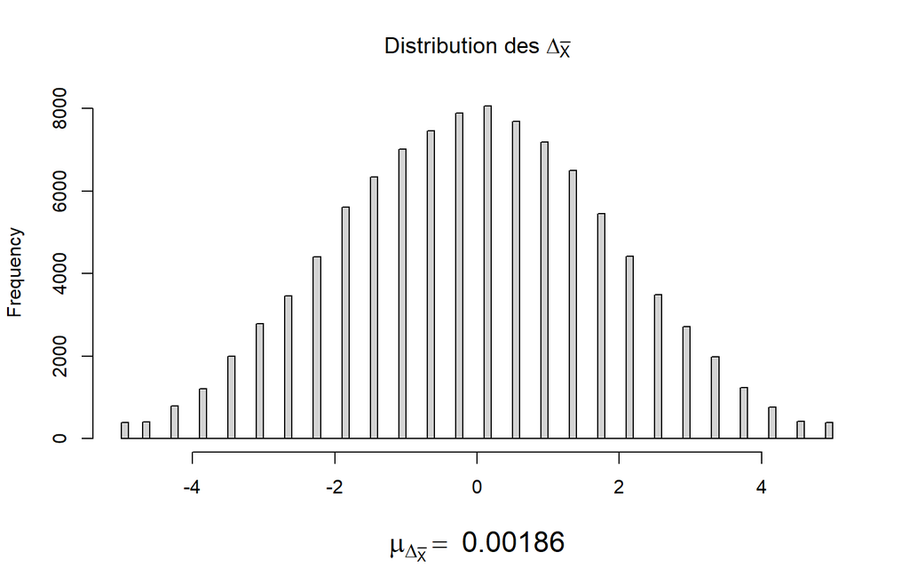

Figure 13.14: Distribution des différences de moyennes obtenues pour une sélection aléatoire de 100,000 permutations formées des nombres de 1 à 10, les 5 premiers et les 5 derniers formant deux groupes indépendants.

Les résultats obtenus ne sont pas très éloignés de ceux obtenus à partir de l’ensemble des permutations possibles. La moyenne de la distribution est très près de 0.0, son écart-type est pratiquement égal à celui obtenu pour l’ensemble des permutations, et les indices de symétrie et de voussure vont dans le sens d’une distribution normale. Ce résultat valide l’utilisation du test de permutations pour la comparaison de deux moyennes indépendantes.

#### 13.3.1.1 Exemple numérique

Supposons deux échantillons indépendants tirés d’une population. La répartition des observations dans les deux groupes peut être considérée comme un parmi un très grand nombre d’arrangements possibles. Plutôt que de ré-échantillonner chacun des échantillons de manière indépendante, on peut combiner les données provenant des deux échantillons, et les redistribuer aléatoirement pour obtenir un nouvel arrangement. En répétant un grand nombre de fois ce processus, calculant la différence entre les estimateurs à chaque fois, on obtient la distribution d’échantillonnage nécessaire.

Pour illustrer la procédure, considérons un ensemble de données générées aléatoirement à partir de paramètres eux-mêmes aléatoires. Les données résultantes sont analogues au tout premier exemple de ce chapitre, à la section Section 13.2.1:

```r
set.seed(150752)

mu1 <- runif(1, 20, 25)     # mu1 choisie au hasard entre 20 et 25
x1 <- rnorm(n = 25,
            mean = mu1,
            sd = 8)         # Échantillon aléatoire tiré d'une distribution normale
mu2 <- mu1 + runif(1, 1, 5) # mu2 égal à mu1 plus une quantité choisie au hasard
x2 <- rnorm(n = 25,
            mean = mu2,
            sd = 8)         # Échantillon aléatoire tiré d'une distribution normale
```

De chacune des deux populations dont les paramètres sont inconnus, on tire un échantillon aléatoire. Les moyennes des deux populations et leur différence sont les paramètres que l’on tente d’estimer. Pour cet exemple, leurs valeurs sont en réalité les suivantes:

**Paramètres**:  
- $\mu_1 = 21.385$  
- $\mu_2 = 25.146$  
- $\mu_1 - \mu_2 = -3.761$

Les estimateurs obtenus des deux échantillons sont les suivants:

**Statistiques**:  
- $\bar{X}_1 = 21.37 \qquad s_{x1} = 9.275$  
- $\bar{X}_2 = 24.417\qquad s_{x2} = 7.125$  
- $\bar{X}_1 - \bar{X}_2 = -3.047$

En théorie, pour des échantillons **aléatoires** et **représentatifs** des populations d’où ils sont tirés, les statistiques observées devraient réfléter les paramètres correspondants.

**Important!**

Encore une fois, les moyennes des deux populations sont affichées, mais uniquement dans un but de comparaisons avec les résultats des analyses à venir. Dans le monde réel, ces paramètres sont inconnues et sont de fait ce que l’on cherche à estimer.

Un test de permutations permettra d’estimer et/ou de vérifier des hypothèses concernant les différences susceptibles d’exister entre les paramètres des deux populations. Pour rappel, ce test se déroule suivant les étapes suivantes:

1. Calcul de la différence de la statistique échantillonnale, entre les deux groupes: on cherche la probabilité d’obtenir une telle valeur, ou une valeur plus extrême…
2. Combinaison des deux groupes pour former un seul ensemble, composé de $N = n_1 + n_2$ observations
3. Permutation de l’ensemble
4. Répartition aléatoire des observations dans les deux groupes, en respectant la taille de chacun
5. Calcul des statistiques et de leur différence, que l’on collige
6. Retour à (2) et répéter un grand nombre de fois ($k$).
7. La distribution des différences observées est la distribution d’échantillonnage dont on a besoin pour compléter le test. À la limite, lorsque $k\rightarrow \infty$, la moyenne de cette distribution est nulle.
8. Évaluation de la probabilité associée à la différence notée en (1), à partir de la distribution obtenue en (7)

Le code R suivant permet d’effectuer ces étapes et les applique 100,000 fois sur les données que nous venons de générer.

```r
g1 <- x1                                   # Observations, Groupe 1
g2 <- x2                                   # Observations, Groupe 2
N <- (n1 <- length(g1))+(n2 <- length(g2)) # Nombre total d'observations
xt <- c(g1, g2)                            # Observations rassemblées
nsig <- 0.05                               # Niveau de signification
ns <- 100000                               # Nombre de permutations à effectuer

calcDiff <- function(x1, x2, N) {
  rd <- sample(xt,
               N,
               replace = FALSE)            # Permutation de l'ensemble des données
  Grp1 <- rd[1:length(x1)]                 # Assignation des n1 premiers scores à Grp1
  Grp2 <- rd[(length(x1) + 1):N]           # Assignation des n2 derniers scores à Grp2
  mean_diff <- mean(Grp1) - mean(Grp2)     # Différence entre les 2 moyennes
  return(mean_diff)
}

xbd <- replicate(ns, calcDiff(g1, g2, N))  # Répéter ns fois le processus
```

En exécutant ce code, on obtient un ensemble de 100,000 différences de moyennes, dont on peut examiner la distribution. La Figure 13.15 affiche ainsi la distribution d’échantillonnage des différences de moyennes résultant de ces opérations.

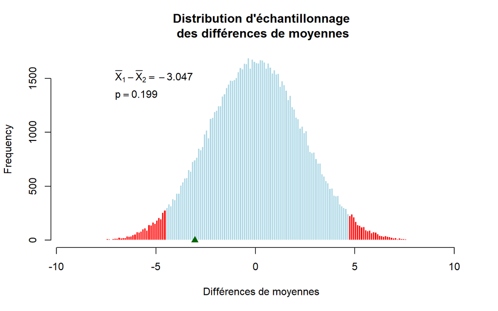

Figure 13.15: Distribution d’échantillonnage des différences de moyennes obtenue par un test de permutations. La différence observée entre les moyennes est représentée par un triangle vert sur l’axe horizontal. Le niveau de signification est α = 0.05 (bilatéral).

Tel qu’attendu pour un test de permutations, la moyenne de la distribution est nulle. Les valeurs de $\Delta_{\bar{X}}$ comprises entre -4.568 et 4.623 sont probables, sous $H_0$. Et la différence observée est l’une d’entre elles. La probabilité d’obtenir une différence égale ou supérieure à celle qui est observée est:

```r
obs_diff <- mean(g1) - mean(g2)
p <- mean(abs(xbd) >= abs(obs_diff))
```

$$p(\Delta_{\bar{X}}>3) = 0.1991$$

Analysons les mêmes données à l’aide de la fonction **boot.two.per()** de la librairie **wBoot**:

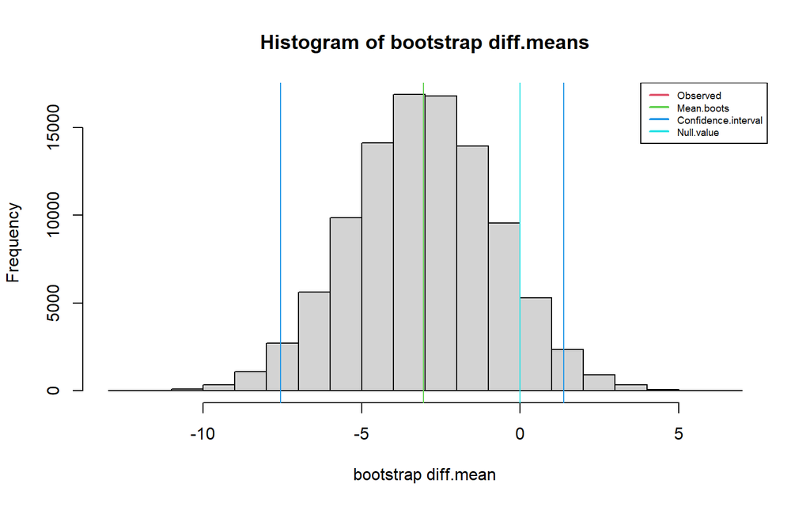

```
#>
#>
#>  RESULTS OF PERCENTILE BOOTSTRAP FOR DIFF.MEAN
#>
#>     SUMMARY Pop.1 Pop.2 n.1 n.2 Statistic  Observed
#>  STATISTICS    g1    g2  25  25 diff.mean -3.046965
#>
#>  BOOTSTRAP Replications      Mean       SE     Bias Percent.bias
#>    SUMMARY        1e+05 -3.052393 2.284415 -0.00543        0.178
#>
#>  HYPOTHESIS Null Alternative P.value
#>        TEST    0   not-equal   0.179
#>
#>  CONFIDENCE Level      Type Confidence.interval
#>    INTERVAL   95% two-sided     (-7.552, 1.383)
```

```r
library(wBoot)
b.moyDiff  <-  boot.two.per(g1,
                            g2,
                            mean,
                            stacked=FALSE,
                            null.hyp=0,
                            alternative="two.sided",
                            conf.level=0.95,
                            R=100000)
print.boot.two(b.moyDiff)
```

L’histogramme illustrant la distribution résultant de la procédure est centré sur la différence observée entre les moyennes, ce qui permet d’obtenir l’intervalle de confiance de la différence des moyennes. Une différence nulle fait partie de cet intervalle, ce qui nous permet de tirer les mêmes conclusions que dans l’analyse précédente.

### 13.3.2 Exemple 10: Test d’hypothèse pour deux moyennes indépendantes

Peut-on affirmer que l’indice de Condition de Vie (CondxVie) moyen en Artibonite est différent de ce qu’on trouve dans le département du Centre?

Cette question de recherche se traduit par les hypothèses statistiques suivantes:

$$H_0:\mu_{Artibonite}-\mu_{Centre}=0$$
$$H_1:\mu_{Artibonite}-\mu_{Centre}\ne 0$$

Appliquons le test de permutations afin d’élucider la question. Nous disposons d’un échantillon de 25 sujets vivant en Artibonite et d’un échantillon de 30 sujets provenant du département du Centre. Le code R suivant génère les données, et en fournit une description.

```r
set.seed(150752)
# Création des sous-populations
subpop1  <-  subset(HaitiPop,(DEPARTEMENT=="1"),CondxVie)
subpop2  <-  subset(HaitiPop,(DEPARTEMENT=="2"),CondxVie)

# Création des échantillons
nA  <-  25
nC  <-  30
xechA  <-  subpop1$CondxVie[sample(1:nrow(subpop1),nA,replace=FALSE)]
xechC  <-  subpop2$CondxVie[sample(1:nrow(subpop2),nC,replace=FALSE)]
MxechA  <-  mean(xechA)      # Moyenne (Artibonite)
SxechA <- sd(xechA)          # Écart-type (Artibonite)
MxechC  <-  mean(xechC)      # Moyenne (Centre)
SxechC <- sd(xechC)          # Écart-type (Centre)
moyDiff  <-  MxechA - MxechC # Différence entre les moyennes
```

**Statistiques**:  
- $\bar{X}_{Art} = 5.372 \qquad s_{Art} = 2.597$  
- $\bar{X}_{Cen} = 7.149\qquad s_{Cen} = 3.657$  
- $\bar{X}_{Art} - \bar{X}_{Cen} = -1.777$

En appliquant le test de permutations, on obtient les résultats suivants, illustrés à la Figure 13.16.

```r
g1 <- xechA
g2 <- xechC
N <- (n1 <- length(g1))+(n2 <- length(g2)) # Nombre total d'observations
xt <- c(g1, g2)                            # Observations rassemblées
nsig <- 0.05                               # Niveau de confiance
ns <- 100000                               # Nombre de permutations à effectuer

calcDiff <- function(x1, x2, N) {
  rd <- sample(xt, N, replace = FALSE)     # Permutation
  mean_diff <- mean(rd[1:length(x1)]) - mean(rd[(length(x1) + 1):N])  # Difference in means
  return(mean_diff)
}

xbd <- replicate(ns, calcDiff(g1, g2, N))
IClim <- quantile(xbd, c(0.025, 0.975))
```

**Paramètres de la distribution de ré-échantillonnage**:

$$\mu_{\bar{X_1}- \bar{X_2}} = 0.004 \qquad \sigma_{\bar{X_1}- \bar{X_2}} = 0.896$$

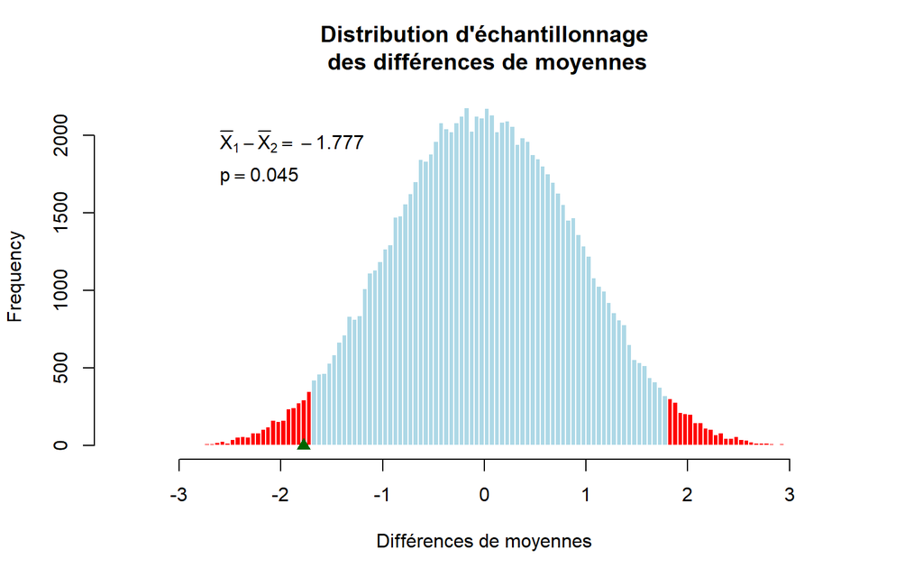

Figure 13.16: Résultats d’un test de permutations et distribution d’échantillonnage des différences de moyennes. Les portions rouges de l’histogramme délimitent les zones de rejet de $H_0$, et le triangle vert sur l’axe horizontal indique la position de la différence observée entre les moyennes. Le niveau de signification est α = 0.05

**Probabilité d’une différence égale ou plus extrême que celle observée**:

$$p(|\bar{X_1}- \bar{X_2}| \ge -1.777)=0.05$$
**Intervalle de valeurs probables (95%)** et **Intervalle de confiance (95%)**:

Pour l’ensemble des différences de moyennes obtenu par le test de permutations, on peut considérer l’intervalle suivant:

$$C\left [-1.719 \leq \bar{X}_1-\bar{X}_2 \leq 1.757 \right ] = 95\%$$

Notons que la moyenne de cette distribution s’approche de 0. L’intervalle contient les différences de moyennes probables pour les différentes permutations que l’on peut former à partir des données regroupées. Il ne permet donc pas d’estimer la différence entre les moyennes des deux populations. Cependant, on peut noter que la différence observée entre les deux moyennes se trouve à l’extérieur de cet intervalle, mettant en évidence qu’elle est peu probable. Notons qu’il est également possible de centrer l’ensemble des différences de moyennes sur la différence observée, tel qu’énoncé dans l’équation Équation 13.12.

$$(\bar{X}_1-\bar{X}_2)_{(CENTRÉ)i}=(\bar{X}_1-\bar{X}_2)_i-\mu_{\bar{X}_1-\bar{X}_2}+(\bar{X}_1-\bar{X}_2)_{obs} \tag{13.12}$$

Sous R, on applique les opérations suivantes:

```r
xbdC <- xbd - mean(xbd) + diffxb # Données centrées sur la différence observée
```

On trouve alors:

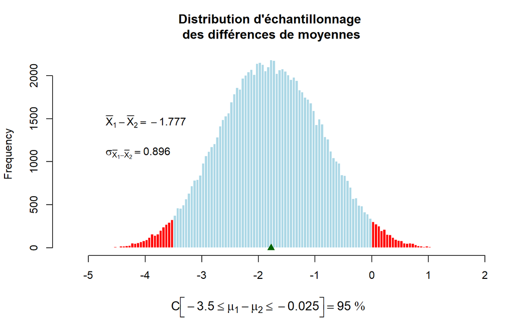

Figure 13.17: Résultats d’un test de permutations et distribution d’échantillonnage des différences de moyennes. Les différences sont centrées sur la différence observée entre les deux moyennes. Entre les portions rouges de l’histogramme, on retrouve l’intervalle de confiance (95%) de la différence entre les moyennes. Le triangle vert sur l’axe horizontal indique la position de la différence observée entre les moyennes.

Dans ce cas, on obtient l’intervalle de confiance de la différence de moyennes, tel que défini à la section Section 13.2.1. On y constate qu’il exclut une différence nulle, telle que spécifiée dans $H_0$.

**Test de signification**:

Les résultats indiquent que la différence observée entre les moyennes des deux échantillons est un événement improbable si $H_0$ est vraie. Ce résultat va à l’encontre de ce que propose $H_0$. On peut rejeter cette hypothèse. La différence observée reflète une réalité au niveau de la population, et on la considère comme statistiquement significative .

En utilisant la fonction **boot.two.per**, on obtient des résultats similaires, illustrés à la Figure 13.18.

```
#>
#>
#>  RESULTS OF PERCENTILE BOOTSTRAP FOR DIFF.MEAN
#>
#>     SUMMARY Pop.1 Pop.2 n.1 n.2 Statistic  Observed
#>  STATISTICS xechA xechC  25  30 diff.mean -1.777067
#>
#>  BOOTSTRAP Replications      Mean        SE     Bias Percent.bias
#>    SUMMARY        1e+05 -1.778499 0.8309853 -0.00143       0.0805
#>
#>  HYPOTHESIS Null Alternative P.value
#>        TEST    0   not-equal  0.0276
#>
#>  CONFIDENCE Level      Type Confidence.interval
#>    INTERVAL   95% two-sided    (-3.44, -0.1826)
```

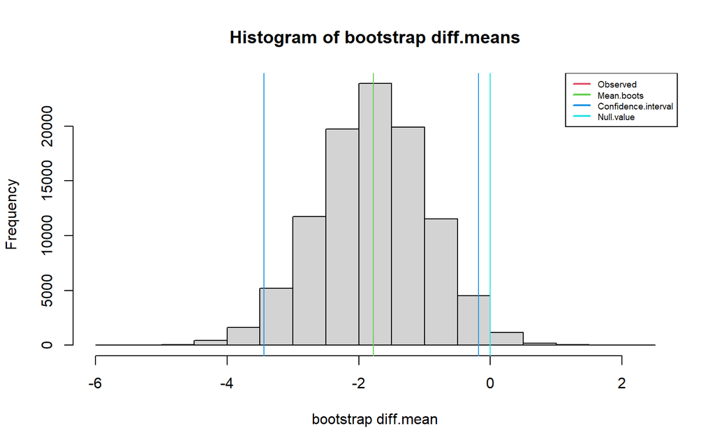

Figure 13.18: Test de permutations à l’aide de la fonction wBoot()

```r
b.moyDiff = wBoot::boot.two.per(xechA,
                                xechC,
                                mean,
                                stacked=FALSE,
                                null.hyp=0,
                                alternative="two.sided",
                                conf.level=0.95,
                                R=100000)

print.boot.two(b.moyDiff)
```

Les résultats sont analogues et conduisent aux mêmes conclusions.

### 13.3.3 Exemple 11: Test d’hypothèse pour deux variances indépendantes

Certaines questions de recherche nécessitent la comparaison de variances. Est-ce que l’indice d’habileté cognitive (HabilCog) est plus homogène dans le département de l’Ouest qu’en Artibonite? Est-ce que l’indice de condition de vie est plus variable chez les femmes que chez les hommes?

La comparaison de deux variances ne repose pas sur leur différence, mais plutôt sur leur rapport, que l’on nomme F (Équation 13.13):

$$F = \frac{s_1^2}{s_2^2}
\tag{13.13}$$

Ce rapport prend toujours une valeur positive, puisqu’une variance ne peut qu’être positive. Si les deux variances sont égales, F = 1.

À titre d’exemple, comparons la variance de l’indice d’habileté cognitive (HabilCog) entre les résidents du département de l’Ouest et ceux d’Artibonite.

1. On forme un premier échantillon de 30 sujets en Artibonite, et un échantillon de 25 sujets dans le département de l’Ouest.
2. On calcule la variance pour chacun des échantillons
3. On obtient le rapport F en divisant la plus grande variance par la plus petite.
4. En utilisant le test de permutations, on obtient un grand nombre de rapports F, desquels on obtient la distribution d’échantillonnage de ce rapport.
5. La probabilité d’obtenir le rapport F observée initialement pour les échantillons ou un rapport plus extrême est évaluée. Rappelons que puisque la variance la plus élevée occupe le numérateur, on ne s’occupera que de l’extrémité supérieure de la distribution.
6. Une décision est prise quant au rejet ou non de $H_0$.

Le code R suivant produit les échantillons nécessaires à l’exercice et en calcule les statistiques descriptives:

```r
set.seed(15776542)
# Création des sous-populations
subpop1 = subset(HaitiPop,(DEPARTEMENT=="8"),HabilCog)
subpop2 = subset(HaitiPop,(DEPARTEMENT=="1"),HabilCog)

# Création des échantillons
nO  <-  25
nA <-  30
xechO <-  subpop1$HabilCog[sample(1:nrow(subpop1),nO,replace=FALSE)]
xechA <-  subpop2$HabilCog[sample(1:nrow(subpop2),nA,replace=FALSE)]
MxechO <- mean(xechO)
MxechA <- mean(xechA)
VxechO <- var(xechO)
VxechA <- var(xechA)
RapF  <-  VxechO / VxechA

xb1 <- round(MxechO, 3)
sd1 <- round(VxechO^0.5, 3)
xb2 <- round(MxechA, 3)
sd2 <- round(VxechA^0.5, 3)
F <- round(RapF, 3)
```

**Statistiques**:  
* $\bar{X}_{Ouest} = 103.456 \qquad s_{Ouest} = 18.117$

- $\bar{X}_{Artib} = 109.338\qquad s_{Artib} = 16.149$
- $F = \frac{s_{Ouest}^2}{s_{Artib}^2} = 1.259$

Les hypothèses statistiques sont:

$H_0:\frac{\sigma_{Ouest}^2}{\sigma_{Artibonite}^2}=1 \qquad H_1:\frac{\sigma_{Ouest}^2}{\sigma_{Artibonite}^2}>1$

Pour obtenir la distribution d’échantillonnage du rapport F, on peut utiliser soit le ré-échantillonnage, soit le test de permutation.

1. **Ré-échantillonnage**

En ré-échantillonnant l’échantillon original 100,000 fois, on obtient les résultats résumés à la Figure 13.19.

Après 100,000 ré-échantillonnages, on trouve que $22.79\%$ des rapports F ont une valeur égale ou plus extrême que $F=1.0$. L’égalité des variances est donc un événement probable. On peut donc conclure qu’il n’y a pas d’évidence pour qu’une différence existe entre les variances des populations des départements d’Artibonite et de l’Ouest, en ce qui concerne les habiletés cognitives. En d’autres termes, l’intervalle délimité par les percentiles $P_{2.5}$ et $P_{97.5}$ contient $F=1.0$, ce qui confirme cette conclusion. La figure Figure 13.19 illustre cette situation.

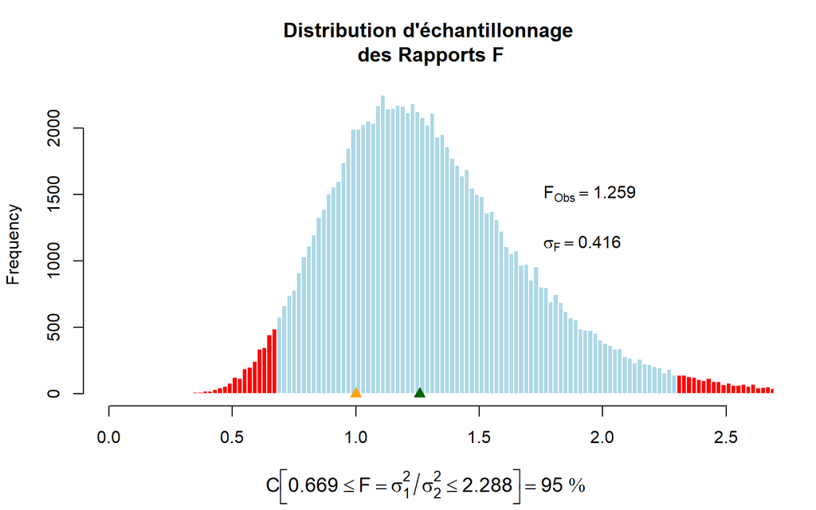

Figure 13.19: Distribution d’échantillonnage de F obtenue par ré-échantillonnage. Le rapport F observé est représenté par un triangle vert sur l’axe horizontal. Il s’agit de fait de la moyenne de la distribution. F=1.0 est représenté par un triangle orange, sur le même axe. Les extrémités de la distribution (en rouge) représentent les zones de rejet de $H_0$, pour $lpha = 0.05$.

2. **Permutations**

En utilisant le test de permutations tel que décrit à la section Section 13.3, on obtient des résultats similaires, résumés dans la Figure 13.20.

```r
# Test de permutation

N  <- length(xechO) + length(xechA) # Nombre total d'observations
xt <- c(xechO,xechA)                # Observations rassemblées
nsig <- .05                         # Niveau de confiance
ns <- 100000                        # Nombre de permutations à effectuer

xbd <- replicate(ns, {
  rd <- sample(xt, N, replace = FALSE)  # Permutations
  v1 <- var(rd[1:length(xechO)])        # Variance du groupe 1
  v2 <- var(rd[(length(xechO) + 1):N])  # Variance du groupe 2
  v1 / v2             # Calcul du rapport F
})

lims <- quantile(xbd, c(0.025,0.975))
p <- ifelse(RapF <= 1, mean(xbd <= RapF), mean(xbd >= RapF))
```

Cette fois, la distribution des rapports F obtenus pour l’ensemble des permutations est centrée sur $F=1.0$, la valeur indiquant l’égalité des deux variances. En comptabilisant le nombre de rapports F égaux ou plus extrêmes que celui observé au niveau des échantillons, on obtient la probabilité d’obtenir $p(F|H_0\; vraie)$.

Après 100,000 permutations des données, on trouve que $22.73\%$ des rapports F ont une valeur égale ou plus extrême que le rapport F observé ($F_{obs}=1.259$). Il n’y a pas évidence pour qu’une différence existe entre les variances des populations des départements d’Artibonite et de l’Ouest, en ce qui concerne les habiletés cognitives. La figure Figure 13.20 illustre la situation.

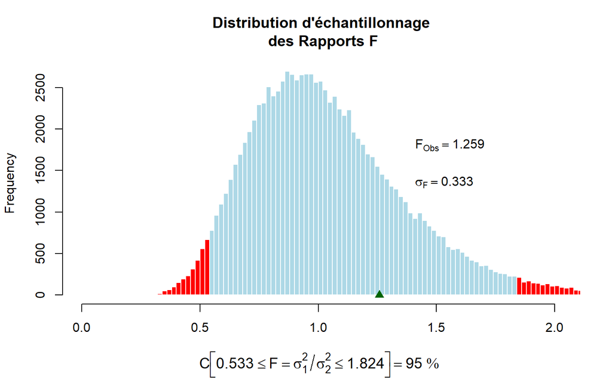

Figure 13.20: Distribution d’échantillonnage obtenue par le test de permutations. Le rapport F observé est indiqué par le triangle vert apparaissant sur l’axe horizontal. Les extrémités de la distribution, en rouge, représentent les zones de rejet de $H_0$.

Les résultats indiquent que la différence observée entre les variances de l’indice HabilCog dans le département de l’Ouest et d’Artibonite est un événement probable (p = 0.2273). Ce résultat va dans le sens de ce que propose $H_0$. On ne peut pas rejeter cette hypothèse. La différence observée ne reflète pas une réalité au niveau de la population, et on la considère comme statistiquement non significative . Il n’y a pas évidence à l’effet que la variance de HabilCog est plus faible dans le département de l’Ouest qu’en Artibonite.

### 13.3.4 Exemple 12: Test d’hypothèse pour deux proportions indépendantes

Peut-on affirmer que la proportion des adultes accordant leur confiance au Candidat A dans le département du Nord est supérieure à cette proportion dans le département de l’Ouest? On dispose d’un échantillon de 250 sujets dans le département du Nord, et de 325 sujets dans de département de l’Ouest pour examiner la question.

```r
# Création des sous-populations
subpopN = subset(HaitiPop,((DEPARTEMENT=="5")&(AGE>=18)),PrefPres)
subpopO = subset(HaitiPop,((DEPARTEMENT=="8")&(AGE>=18)),PrefPres)

# Création des échantillons
nN = 250
nO = 325
xechN = subpopN$PrefPres[sample(1:nrow(subpopN),nN,replace=FALSE)]==1
xechO = subpopO$PrefPres[sample(1:nrow(subpopO),nO,replace=FALSE)]==1
pN <- mean(xechN)
pO <- mean(xechO)
```

**Statistiques**:

- $p_{Nord} = 0.54$
- $p_{Ouest} = 0.274$
- $p_{Nord}-p_{Ouest} = 0.266$

Les hypothèses statistiques sont:

$H_0:\pi_{Nord}-\pi_{Ouest}=0 \qquad H_1:\pi_{Nord}-\pi_{Ouest}>0$

On note une différence entre les proportions observées pour les échantillons. Mais est-ce que cette différence reflète une réalité au niveau des populations d’où proviennent ces échantillons, ou peut-on croire que la différence observée est le simple fait des fluctuations d’échantillonnage?

En utilisant la fonction **boot.two.per()**, de la librairie **wBoot**, on obtient les résultats suivants:

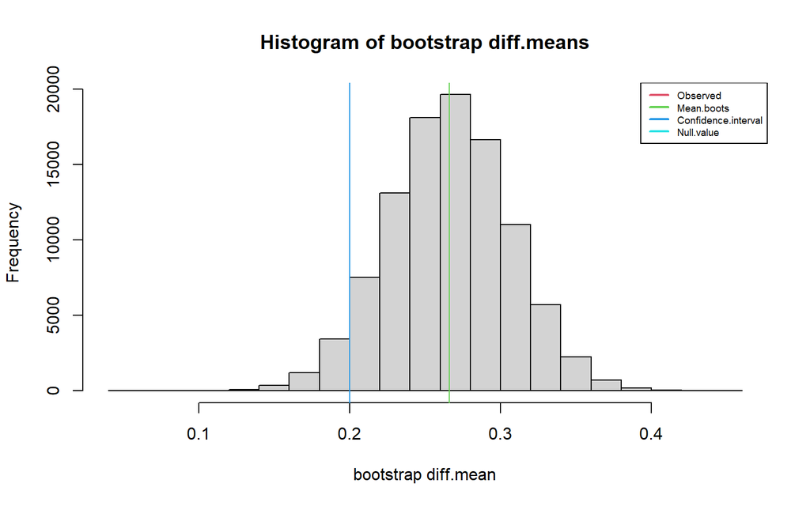

```
#>
#>
#>  RESULTS OF PERCENTILE BOOTSTRAP FOR DIFF.MEAN
#>
#>     SUMMARY Pop.1 Pop.2 n.1 n.2 Statistic  Observed
#>  STATISTICS xechN xechO 250 325 diff.mean 0.2661538
#>
#>  BOOTSTRAP Replications      Mean         SE     Bias Percent.bias
#>    SUMMARY        1e+05 0.2662171 0.04013628 6.32e-05       0.0237
#>
#>  HYPOTHESIS Null  Alternative   P.value
#>        TEST    0 greater-than P < 0.001
#>
#>  CONFIDENCE Level        Type Confidence.interval
#>    INTERVAL   95% lower-bound           0.2 (LCB)
```

```r
b.Diff  <-  wBoot::boot.two.per(xechN, xechO,
                                parameter=mean,
                                null.hyp=0,
                                alternative="greater",
                                conf.level=0.95,
                                R=100000,
                                stacked=FALSE)
wBoot::print.boot.two(b.Diff)
```

Ces résultats indiquent que la différence observée entre les proportions de préférence pour le Candidat A dans le département du Nord et celui de l’Ouest est un événement improbable (p = 0 ) . Ce résultat va à l’encontre de ce que propose $H_0$. On peut rejeter cette hypothèse. La différence observée reflète une réalité au niveau de la population, et on la considère comme statistiquement significative . Il y a évidence voulant que la proportion d’appui au Candidat A soit plus élevée dans le département du Nord que dans celui de l’Ouest.

### 13.3.5 Exemple 13: Test d’hypothèse pour deux consensus

Est-ce que le niveau de consensus concernant le projet d’une nouvelle Constitution au pays est différent lorsqu’on considère les populations des régions nordiques (départements du Nord-Est, du Nord et du Nord-Ouest) et l’ensemble des départements du Centre et de l’Ouest? On dispose d’un échantillon de 250 sujets dans les départements du Nord, et de 325 sujets dans les départements du Centre et de l’Ouest pour examiner cette question.

```r
cons = function(x){
  tbl = table(x)
  cns = agrmt::consensus(tbl)
  return(cns)
}

subpopN = subset(HaitiPop,((DEPARTEMENT %in% c("5","6","7"))&(AGE>=18)),OpinConst)
subpopO = subset(HaitiPop,((DEPARTEMENT %in% c("2","8"))&(AGE>=18)),OpinConst)

nN = 250
nO = 325
xechN = subpopN$OpinConst[sample(1:nrow(subpopN),nN,replace=FALSE)]==1
xechO = subpopO$OpinConst[sample(1:nrow(subpopO),nO,replace=FALSE)]==1
cN <- cons(xechN)
cO <- cons(xechO)
```

**Statistiques**:

- $CNS_{Nord} = 0.657$
- $CNS_{Ouest} = 0.149$
- $CNS_{Nord}-CNS_{Ouest} = 0.508$

On note une différence entre les consensus observés au niveau des échantillons. Mais est-ce que cette différence reflète une réalité au niveau des populations d’où proviennent ces échantillons, ou peut-on croire que la différence observée est le simple fait des fluctuations d’échantillonnage?

Les hypothèses statistiques sont:

$H_0:CNS_{Nord}-CNS_{Ouest}= 0$

$H_0:CNS_{Nord}-CNS_{Ouest}\neq 0$

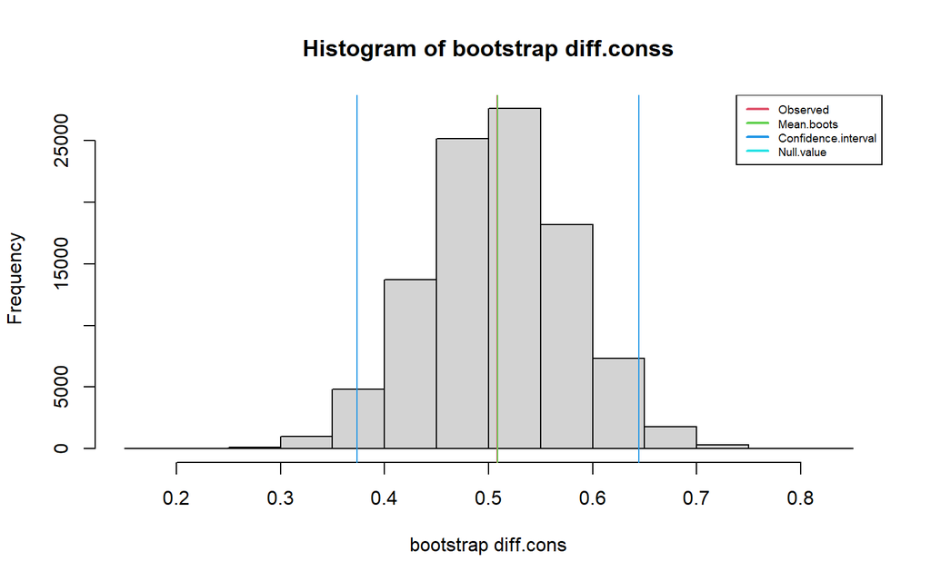

```
#>
#>
#>  RESULTS OF PERCENTILE BOOTSTRAP FOR DIFF.CONS
#>
#>     SUMMARY Pop.1 Pop.2 n.1 n.2 Statistic  Observed
#>  STATISTICS xechN xechO 250 325 diff.cons 0.5081014
#>
#>  BOOTSTRAP Replications      Mean         SE    Bias Percent.bias
#>    SUMMARY        1e+05 0.5089617 0.06932988 0.00086        0.169
#>
#>  HYPOTHESIS Null Alternative   P.value
#>        TEST    0   not-equal P < 0.001
#>
#>  CONFIDENCE Level      Type Confidence.interval
#>    INTERVAL   95% two-sided    (0.3736, 0.6446)
```

```r
b.Diff = wBoot::boot.two.per(xechN,xechO,
                    parameter=cons,
                    null.hyp=0,
                    alternative="two.sided",
                    conf.level=0.95,
                    R=100000,
                    stacked=FALSE)
wBoot::print.boot.two(b.Diff)
```

```r
p = b.Diff$p.value
```

Les résultats indiquent que la différence observée entre les niveaux de consensus diffèrent entre les régions nordiques et le groupe formé des départements du Centre et de l’Ouest est un événement improbable (p = 10^{-5} ) . Ce résultat va à l’encontre de ce que propose $H_0$. On peut rejeter cette hypothèse. La différence observée reflète une réalité au niveau de la population, et on la considère comme statistiquement significative . Il y a évidence voulant que le niveau de consensus dans la population nordique diffère de celui de l’ensemble composé des départements du Centre et de l’Ouest.

### 13.3.6 Exemple 14: Test d’hypothèse pour Rapport de Variation

On se souviendra qu’une mesure de dispersion pour variables nominales est donnée par la proportion des observations qui ne font pas partie de la catégorie modale. Il s’agit d’une quantité qui, étant obtenue d’un échantillon, peut servir d’estimateur du paramètre correspondant de la population.

Posons la question de recherche suivante: ‘**Est-ce que le rapport de variation de la distribution des appuis aux différents candidats à la présidence diffère entre les trois départements du nord et les quatre départements du sud?**’

Le code R suivant permettra, dans un premier temps, d’obtenir les échantillons nécessaires, et ensuite, de vérifier l’hypothèse d’égalité dans le RV des deux régions du pays. Il nous est permis d’utiliser un échantillon de 400 sujets dans les régions du Nord, et de 350 sujets dans les régions du sud. Le code R suivant génère les données et calcule les statistiques requises:

```r
subpopN = subset(HaitiPop,((DEPARTEMENT %in% c("5","6","7"))&(AGE>=18)),PrefPres)
subpopS = subset(HaitiPop,((DEPARTEMENT %in% c("3","4","9","10"))&(AGE>=18)),PrefPres)

nN <- 400
nS <- 350
xechN <- subpopN$PrefPres[sample(1:nrow(subpopN),nN,replace=FALSE)]
xechS <- subpopS$PrefPres[sample(1:nrow(subpopS),nS,replace=FALSE)]
RVech <- rvDiff(xechN,xechS)
```

**Statistiques**:

- $RV_{Nord} = 0.415$
- $RV_{Sud} = 0.649$
- $RV_{Nord}-RV_{Sud} = -0.234$

Les hypothèses statistiques sont:

$H_0:RV_{Nord}-RV_{Sud}=0 \qquad H_0:RV_{Nord}-RV_{Sud}\neq 0$

On note une différence entre les Rapports de Variation au niveau des échantillons. Mais est-ce que cette différence reflète une réalité au niveau des populations d’où proviennent ces échantillons, ou peut-on croire que la différence observée est le simple fait des fluctuations d’échantillonnage?

Pour répondre à cette question, procédons au test de permutations (100,000 réplications) :

```r
g1 <- xechN
g2 <- xechS
N <- (n1 <- length(g1))+(n2 <- length(g2)) # Nombre total d'observations
xt <- c(g1, g2)                            # Observations rassemblées
nsig <- 0.05                               # Niveau de confiance
ns <- 100000                               # Nombre de permutations à effectuer

calcDiff <- function(x1, x2, N) {
  rd <- sample(xt, N, replace = FALSE)     # Permutation
  RV_diff <- rvDiff(rd[1:length(x1)], rd[(length(x1) + 1):N])  # Difference in means
  return(RV_diff[[3]])
}

xbd <- replicate(ns, calcDiff(g1, g2, N))
IClim <- quantile(xbd, c(0.025, 0.975))
```

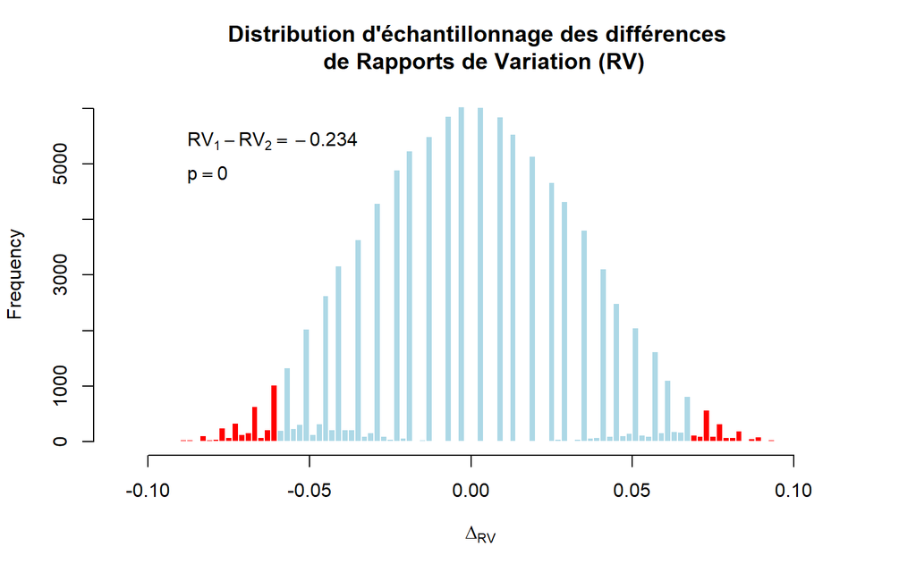

La différence observée entre les deux rapports de variation ($\Delta_{RV}=-0.2336$) se trouve largement en dehors de l’intervalle des valeurs probables sous $H_0$. Une telle différence est par conséquent peu probable et nous amène à rejeter $H_0$.  
On obtient des résultats similaires à l’aide de la fonction **boot.two.per()**. Dans ce cas, il est nécessaire de définir une fonction (Listing 13.4) pour calculer le rapport de variation (**parameter = RV**). On obtient alors les résultats suivants:

```
#>
#>
#>  RESULTS OF PERCENTILE BOOTSTRAP FOR DIFF.RV
#>
#>     SUMMARY Pop.1 Pop.2 n.1 n.2 Statistic   Observed
#>  STATISTICS xechN xechS 400 350   diff.RV -0.2335714
#>
#>  BOOTSTRAP Replications       Mean         SE      Bias Percent.bias
#>    SUMMARY        1e+05 -0.2336071 0.03537313 -3.57e-05       0.0153
#>
#>  HYPOTHESIS Null Alternative   P.value
#>        TEST    0   not-equal P < 0.001
#>
#>  CONFIDENCE Level      Type Confidence.interval
#>    INTERVAL   95% two-sided  (-0.3021, -0.1639)
```

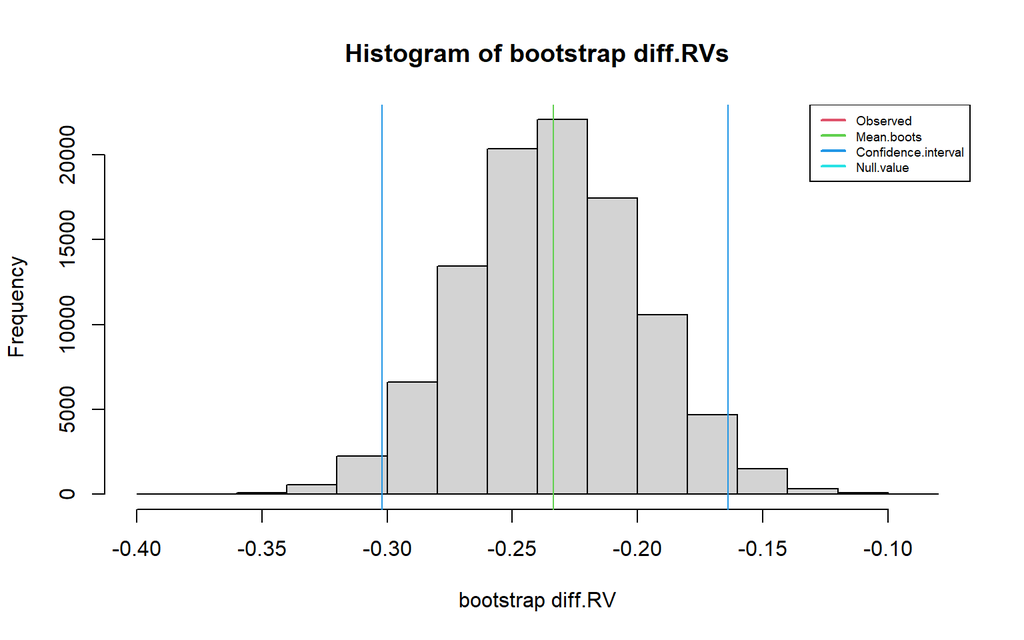

Figure 13.22: Distribution de ré-échantillonnage des Rapports de Variation

L’intervalle de confiance pour la différence de rapports de variation est:

$$C[-0.302\le RV \le -0.164] = 95\%$$

Cet intervalle exclut une différence nulle, justifiant le rejet de $H_0$.

Plus formellement, les résultats indiquent que la différence observée entre les Rapports de Variation dans les départements du Nord et dans les départements du Sud est un événement improbable (p = 10^{-5} ) . Ce résultat va à l’encontre de ce que propose $H_0$. On peut rejeter cette hypothèse. La différence observée reflète une réalité au niveau de la population, et on la considère comme statistiquement significative . Il y a évidence voulant que les rapports de variations dans les deux pôles du pays soient différents l’un de l’autre.

## 13.4 Test d’hypothèse pour groupes indépendants: Approche théorique

Les distributions d’échantillonnage théoriques qui ont permis l’estimation de différences de moyennes (que les écarts-types des populations soient connus ou non), de variances ou de proportions seront à nouveau utilisées dans un contexte de vérification d’hypothèse.

### 13.4.1 Exemple 15: Test d’hypothèse pour deux moyennes indépendantes, $\sigma_1$ et $\sigma_2$ connus

Reprenons l’exemple 10 afin d’illustrer un test d’hypothèse concernant la différence entre deux moyennes indépendantes, pour de grands échantillons, ou lorsque les écarts-types des populations d’où sont tirés ces échantillons sont connus.

Peut-on affirmer que l’indice de Condition de Vie (CondxVie) moyen en Artibonite est différent de ce qu’on trouve dans le département du Centre?

Cette question de recherche se traduit par les hypothèses statistiques suivantes:

$$H_0:\mu_{Artibonite}-\mu_{Centre}=0$$
$$H_1:\mu_{Artibonite}-\mu_{Centre}\ne 0$$

On sait que la distribution d’échantillonnage nécessaire à la vérification de $H_0$ est de nature gaussienne, et que sa moyenne $(\mu_{\bar X_1-\bar X_2})$ est égale à la différence des moyennes au niveau des populations $(\mu_1-\mu_2)$. On sait également que l’erreur-standard des différences de moyennes est:

$$\sigma_{\bar X_1-\bar X_2}=\sqrt{\frac{\sigma_1^2}{n_1} +\frac{\sigma_2^2}{n_2}} \tag{13.14}$$

La procédure consiste donc à obtenir la statistique échantillonnale (la différence entre les moyennes des échantillons), d’évaluer la distance standardisée qui sépare cette statistique du paramètre de la population tel que spécifié dans $H_0$, pour finalement calculer la probabilité de cet événement ou d’un événement plus extrême.

Générons un échantillon aléatoire de chacun des départements concernés:

```r
# Création des sous-populations
subpop1  <-  subset(HaitiPop,(DEPARTEMENT=="1"),CondxVie)
subpop2  <-  subset(HaitiPop,(DEPARTEMENT=="2"),CondxVie)

# Création des échantillons
nA  <-  25
nC  <-  30
xechA  <-  subpop1$CondxVie[sample(1:nrow(subpop1),nA,replace=FALSE)]
xechC  <-  subpop2$CondxVie[sample(1:nrow(subpop2),nC,replace=FALSE)]
MxechA  <-  mean(xechA)
SxechA <- sd(xechA)
MxechC  <-  mean(xechC)
SxechC <- sd(xechC)
moyDiff  <-  MxechA - MxechC
sig1 <- sd(subpop1$CondxVie)
sig2 <- sd(subpop2$CondxVie)
```

**Statistiques**:  
- $\bar{X}_{Art} = 6.678 \qquad s_{Art} = 2.797$  
- $\bar{X}_{Cen} = 5.381\qquad s_{Cen} = 2.903$  
- $\bar{X}_Art{} - \bar{X}_{Cen} = 1.297$

Pour les besoins de la discussion, on a obtenu les écarts-types des deux populations. Cependant, dans le monde réel, ces quantités ne sont pas connues et on doit les estimer à partir des données échantillonnales. Donc, le Bureau des Statistiques ont certifié que:

- $\sigma_{Art} = 3.466$
- $\sigma_{Cen} = 3.471$

De ces résultats, on obtient l’erreur-standard des différences de moyennes:

$$\sigma_{\bar X_1-\bar X_2}=\sqrt{\frac{\sigma_1^2}{n_1} +\frac{\sigma_2^2}{n_2}}= \sqrt{\frac{3.466^2}{25} +\frac{3.471^2}{30}}=0.939$$
La statistique de vérification devient alors:

$$Z=\frac {(\bar X_{Artibonite}-\bar X_{Centre})-(\mu_{Artibonite}-\mu_{Centre})}{\sigma_{\bar X_{Artibonite}-\bar X_{Centre}}} = \frac {(1.297)-0}{0.939}=1.381$$

Ces résultats indiquent que la probabilité d’obtenir une différence telle que $\bar X_{Artibonite}-\bar X_{Centre} = 1.297$ est supérieure au niveau de signification $\alpha=0.05$, supposant que $H_0$ est vraie. De ce fait, on ne rejette pas $H_0$. Nous n’avons pas suffisamment d’évidence voulant qu’il y ait une différence de l’indice de condition de vie moyen entre les départements d’Artibonite et du Centre.

### 13.4.2 Exemple 16: Test d’hypothèse pour deux moyennes indépendantes, $\sigma_1$ et $\sigma_2$ inconnus, petits échantillons

Considérons maintenant que les écarts-types des populations d’où sont tirés les échantillons ne sont pas connus. On doit donc les estimer à partir des données échantillonnales. En conséquence, compte tenu du fait que dans une telle situation la dispersion des populations est sous-estimée, la distribution de Student est le modèle le plus approprié pour le calcul des probabilités requises pour le test d’hypothèse. De plus, l’erreur-standard des différences de moyennes s’obtient en combinant les variances des deux échantillons.

Pour les données de l’exemple précédent, les statistiques descriptives calculées pour chaque échantillon sont les suivantes:

**Statistiques**:  
- $\bar{X}_{Art} = 6.678 \qquad s_{Art} = 2.797 \qquad s_{Art}^2 = 7.825$  
- $\bar{X}_{Cen} = 5.381\qquad s_{Cen} = 2.903 \qquad s_{Cen}^2 = 8.43$  
- $\bar{X}_Art{} - \bar{X}_{Cen} = 1.297$

De manière à obtenir une meilleure estimation de la dispersion des données au niveau de la population, on obtient une combinaison pondérée des variances:

$$s_C^2=\frac{(n_1-1)s_1^2+(n_2-1)s_2^2}{n_1+n_2-2}=\frac{(25 -1)(7.825) + (30-1)8.43)}{25+30-2}=8.156$$

Cette quantité permet une estimation de l’erreur-standard des différences de moyennes:

$$s_{\bar X_1-\bar X_2}=\sqrt{\frac{s_A^2}{n_A}+\frac{s_C^2}{n_C}}= \sqrt{\frac{8.156}{25}+\frac{8.156}{30}}=0.7733775$$

Finalement, la statistique $t$ évalue la distance séparant la différence observée entre les moyennes ($\bar X_{Artibonite}-\bar X_{Centre}$) et la différence postulée au niveau des populations ($\mu_{Artibonite}-\mu_{Centre}$), tenant compte de la dispersion sous la distribution de Student:

$$t=\frac {(\bar X_{Art}-\bar X_{Cen})-(\mu_{Art}-\mu_{Cen})}{s_{\bar X_{Art}-\bar X_{Cen}}} =\frac {(1.297)-0}{0.773}=1.678$$

Sous R, la fonction **t.test()** effectue toutes les opérations décrites dans cette section. Pour le présent exemple, le tout se résume à la commande suivante:

```r
res <- t.test(xechA, xechC,
       alternative="two.sided",
       mu=0,
       var.equal=TRUE,
       conf.level=0.95)
res
```

```
#>
#>  Two Sample t-test
#>
#> data:  xechA and xechC
#> t = 1.6777, df = 53, p-value = 0.0993
#> alternative hypothesis: true difference in means is not equal to 0
#> 95 percent confidence interval:
#>  -0.2537159  2.8486817
#> sample estimates:
#> mean of x mean of y
#>  6.678479  5.380996
```

La situation est illustrée et résumée dans la Figure 13.23, obtenue à l’aide de la fonction **t.Distr()** (Listing 13.6):

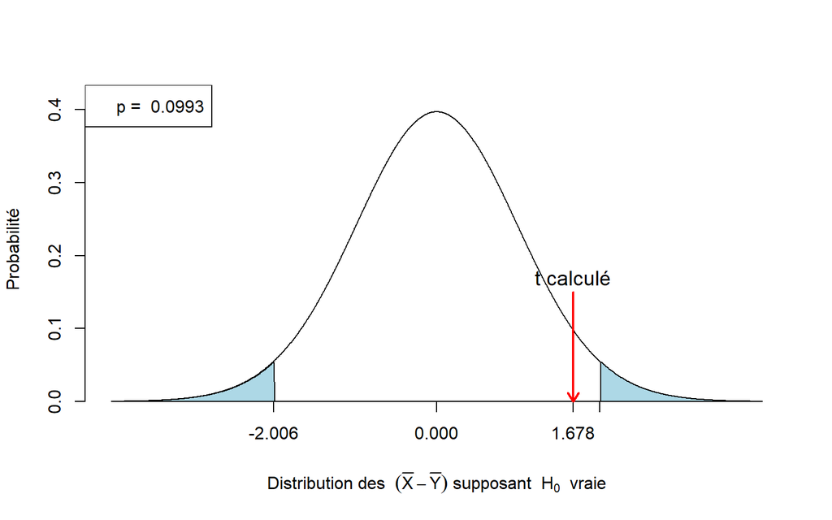

Figure 13.23: Distribution de Student: Exemple 16

Notons qu’un test unilatéral aurait conduit à des résultats différents. Par exemple, pour les hypothèses:

$$H_0:\mu_{Art}-\mu_{Cen}=0 \qquad H_1:\mu_{Art}-\mu_{Cen}< 0$$

Dans ce cas, la valeur de $t$ ne change pas, mais l’ensemble de la zone de rejet se retrouve à gauche de la distribution, composant 5% de la distribution:

```r
res <- t.test(xechA, xechC,
       alternative="less",
       mu=0,
       var.equal=TRUE,        # variances combinées
       conf.level=0.95)
res
```

```
#>
#>  Two Sample t-test
#>
#> data:  xechA and xechC
#> t = 1.6777, df = 53, p-value = 0.9504
#> alternative hypothesis: true difference in means is less than 0
#> 95 percent confidence interval:
#>      -Inf 2.592207
#> sample estimates:
#> mean of x mean of y
#>  6.678479  5.380996
```

[figure not shown]

Figure 13.24: Distribution de Student illustrant une hypothèse unilatérale gauche, pour l’exemple 16

#### 13.4.2.1 Postulats

La comparaison de moyennes indépendantes requiert le respect des postulats suivants:

- Les populations d’où sont tirés les échantillons sont distribuées normalement
- Les observations sont indépendantes les unes des autres, à la fois à l’intérieur des groupes, et entre ces mêmes groupes
- Les variances des populations d’où sont tirés les échantillons sont homogènes (égales)

Lorsque les variances sont hétérogènes (ce qu’on peut vérifier avec une comparaison de variances indépendantes), il convient d’apporter une correction. Cette correction implique une redéfinition du nombre de degrés de liberté, qui diminuera en fonction de la différence entre les variances. Formellement, le nombre de degrés de liberté devient (Équation 13.15):

$$dl'=\frac{{{\left( \frac{s_{1}^{2}}{{{n}_{1}}}+\frac{s_{2}^{2}}{{{n}_{2}}} \right)}^{2}}}{\frac{{{\left( \frac{s_{1}^{2}}{{{n}_{1}}} \right)}^{2}}}{{{n}_{1}}-1}+\frac{{{\left( \frac{s_{2}^{2}}{{{n}_{2}}} \right)}^{2}}}{{{n}_{2}}-1}} \tag{13.15}$$

Cette correction se traduit donc par une diminution du nombre de degrés de liberté et par conséquent augmente la dispersion de la distribution de Student. Les valeurs de $t$ délimitant les zones de rejet de $H_0$ augmentent et il devient plus difficile de rejeter cette hypothèse. L’ensemble de la procédure porte le nom de **test de Welch**. Il est identique au test $t$, sauf en ce qui concerne $dl$. Sous R, il suffit de spécifier l’argument **var.equal=FALSE** de la fonction **t.test()**:

```r
res <- t.test(xechA, xechC,
       alternative="less",
       mu=0,
       var.equal=FALSE,      # Test de Welch
       conf.level=0.95)
res
```

```
#>
#>  Welch Two Sample t-test
#>
#> data:  xechA and xechC
#> t = 1.6835, df = 51.851, p-value = 0.9509
#> alternative hypothesis: true difference in means is less than 0
#> 95 percent confidence interval:
#>      -Inf 2.588261
#> sample estimates:
#> mean of x mean of y
#>  6.678479  5.380996
```

Le nombre de degrés de liberté corrigés est $dl= 51.851$, une très légère réduction qui dans les faits n’affecte que très peu la probabilité associée au $t$ observé. Les résultats sont semblables aux précédents parce qu’au départ, les variances sont relativement homogènes. La différence aurait été plus prononcée pour des variances réellement hétérogènes.

Dans ce cas précis, la différence est négligeable et ne change en rien la conclusion du test d’hypothèse.

Lorsque l’écart entre les variances s’agrandit, les résultats peuvent en être affectés de manière plus importante. Considérons des échantillons de taille $n=10$, le premier étant tiré d’une population caractérisée par $(\mu=50,~~\sigma=4)$, et le second d’une population caractérisée par $(\mu=51,~~\sigma=16)$:

```r
set.seed(071552)
x1 <- rnorm(10, 50, 4)
x2 <- rnorm(10, 51, 16)
```

En appliquant un test $t$ en considérant que les variances sont homogènes (**var.equal = TRUE**) et hétérogènes (**var.equal = FALSE**), on trouve:

```r
res1 <- t.test(x1, x2,
               alternative="less",
               mu=0,
               var.equal=TRUE,
               conf.level=0.95)
res2 <- t.test(x1, x2,
               alternative="less",
               mu=0,
               var.equal=FALSE,
               conf.level=0.95)
```

- $dl$ calculé en supposant des variances égales : 18
- $dl$ calculé en supposant des variances inégales: 11.218

Les valeurs critiques délimitant la zone de rejet pour une hypothèse directionnelle à gauche et $\alpha=0.05$ sont:

- Variances supposées égales : -1.734
- Variances supposées inégales: -1.793

Cette différence pourra avoir des conséquences sur le rejet ou non de $H_0$, car les probabilités sont affectées proportionnellement:

- Variances supposées égales : p = 0.029
- Variances supposées inégales: p = 0.034

Certains auteurs suggèrent de toujours utiliser le test de Welch puisque si les variances sont homogènes, les résultats seront identiques à ceux d’un test-t régulier, et dans le cas contraire la correction sera appliquée.

#### 13.4.2.2 Puissance Statistique: Test-t pour échantillons indépendants

Les concepts fondamentaux concernant la puissance statistique ont été exposés dans le chapitre 9. Ces concepts trouvent également une application dans le cas de la comparaison de deux moyennes indépendantes. Dans ce cas, on pourra calculer l’importance de l’effet, $d$, défini par l’Équation 13.16.

$$d=\frac{\left |\bar X_1-\bar X_2 \right |}{\sqrt{s_C^2}} =\frac{\left |\bar X_1-\bar X_2 \right |}{\sqrt{\frac{(n_1-1) s_1^2+ (n_2-1)s_2^2}{n_1+n_2-2}}}
\tag{13.16}$$

On peut également obtenir l’erreur-standard de $d$ ainsi que son intervalle de confiance, utilisant l’Équation 13.17 et l’Équation 13.18.

$$s_d=\sqrt{\frac{n_1+n_2}{n_1n_2}+\frac{d^2}{2(n_1+n_2)}}
\tag{13.17}$$

$$C[d-t_{dl;\alpha/2}s_d \le \delta \le d+t_{dl;\alpha/2}s_d ]
\tag{13.18}$$

### 13.4.3 Exemple 17: Test d’hypothèse pour deux variances indépendantes

L’exemple 8 a été l’occasion d’introduire la distribution d’échantillonnage des rapports de variances. Rappelons que le rapport entre deux variances indépendantes, que l’on nomme $F$, permet d’évaluer la différence entre ces variances: des variances égales produiront $F=1$ et si la plus grande variance occupe le numérateur du rapport, alors toute différence se traduira par une valeur s’éloignant de ce minimum, en proportion de son importance. Rappelons également que la distribution F est déterminée par deux paramètres: les nombres de degrés de liberté pour le numérateur et pour le dénominateur du rapport.

> Est-ce que l’indice d’habileté cognitive (HabilCog) est plus homogène dans le département de l’Ouest qu’en Artibonite?

```r
# Création des sous-populations
subpop1 = subset(HaitiPop,(DEPARTEMENT=="8"),HabilCog)
subpop2 = subset(HaitiPop,(DEPARTEMENT=="1"),HabilCog)

# Création des échantillons
nO  <-  25
nA <-  30
xechO <-  subpop1$HabilCog[sample(1:nrow(subpop1),nO,replace=FALSE)]
xechA <-  subpop2$HabilCog[sample(1:nrow(subpop2),nA,replace=FALSE)]
MxechO <- mean(xechO)
MxechA <- mean(xechA)
VxechO <- var(xechO)
VxechA <- var(xechA)
RapF  <-  max(VxechO, VxechA) / min(VxechO, VxechA)
```

Les hypothèses statistiques sont:

$H_0:\frac{\sigma_{Artibonite}^2}{\sigma_{Ouest}^2}=1 \qquad H_1:\frac{\sigma_{Artibonite}^2}{\sigma_{Ouest}^2}>1$

La distribution F théorique est déterminée par les deux nombres de degrés de liberté:

$dl_{Ouest} = n_{Ouest} - 1=25-1=24$  
$dl_{Artibonite} = n_{Artibonite} - 1=30-1=29$

$F=\frac{s_{Artibonite}^2}{s_{Ouest}^2}=\frac{219.639}{166.758} = 1.317$

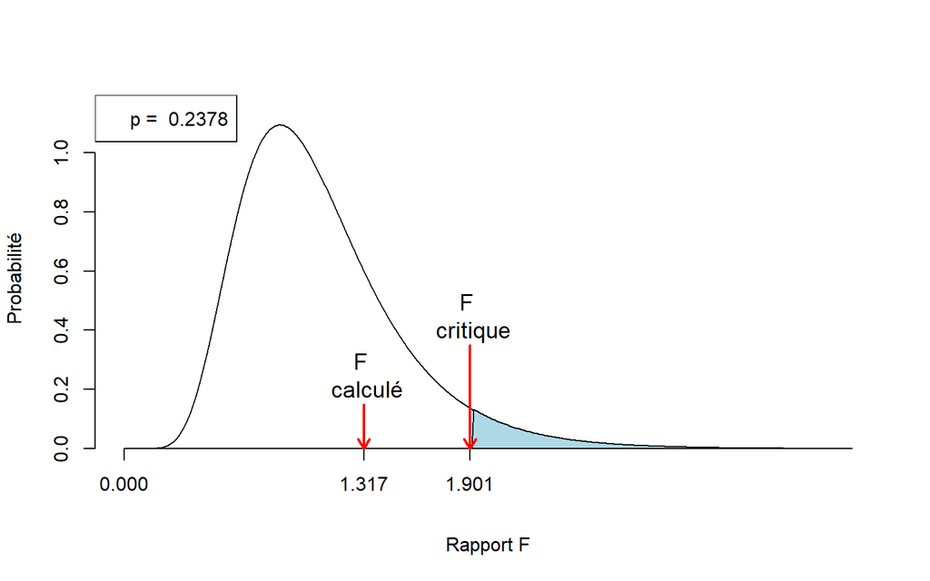

On trouve donc que le rapport F ne s’éloigne pas suffisamment de $1.0$ pour qu’il y ait évidence d’une différence entre les variances des deux populations.

### 13.4.4 Exemple 18: Test d’hypothèse pour deux proportions indépendantes

Afin d’illustrer l’approche théorique dans le cas de test d’hypothèse concernant la différence entre deux proportions indépendantes, considérons l’exemple 12.

> Peut-on affirmer que la proportion des adultes accordant leur confiance au Candidat A dans le département du Nord est supérieure à cette proportion dans le département de l’Ouest?

On dispose d’un échantillon de 250 sujets dans le département du Nord, et de 325 sujets dans de département de l’Ouest pour examiner la question.

```r
# Création des sous-populations
subpopN = subset(HaitiPop,((DEPARTEMENT=="5")&(AGE>=18)),PrefPres)
subpopO = subset(HaitiPop,((DEPARTEMENT=="8")&(AGE>=18)),PrefPres)

# Création des échantillons
nN = 250
nO = 325
xechN = subpopN$PrefPres[sample(1:nrow(subpopN),nN,replace=FALSE)]==1
xechO = subpopO$PrefPres[sample(1:nrow(subpopO),nO,replace=FALSE)]==1
pN <- mean(xechN)
pO <- mean(xechO)
```

**Statistiques**:

- $p_{Nord} = 0.572$
- $p_{Ouest} = 0.292$
- $p_{Nord}-p_{Ouest} = 0.28$

Les hypothèses statistiques sont:

$H_0:\pi_{Nord}-\pi_{Ouest}=0 \qquad H_1:\pi_{Nord}-\pi_{Ouest}>0$

La distribution d’échantillonnage des différences des proportions, on l’a dit, possède les caractéristiques suivantes:

Ce résultat nous permet d’affirmer qu’il y a évidence à l’effet que la proportion des gens en âge de voter favorisant le candidat A dans le département du Nord est supérieure à la proportion que l’on observe dans le département de l’Ouest, au seuil de signification $\alpha=0.05$.

## 13.5 Estimation: deux échantillons corrélés (dépendants)

Lorsque deux échantillons sont dépendants (ou corrélés, ou appariés) et que l’objectif d’une analyse est d’évaluer la différence pouvant exister entre ces échantillons, que ce soit concernant leur moyenne, leur variance, ou toute autre statistique pertinente pour la question de recherche qui est posée, il est nécessaire de tenir compte de la relation existant entre les deux ensembles de données. Une approche que l’on peut utiliser pour cette prise en compte est de considérer les différences observées entre chaque paire de données. Par exemple, pour des échantillons indépendants, on s’intéresse à évaluer $(\bar {X_1} - \bar {X_2})$. Pour des données corrélées, on examinera d’abord $(X_{i,Condx_1} - X_{i,Condx_2})$ pour chaque paire d’observations. Le résultat est une nouvelle variable formée de ces différences. Dans le cas d’une comparaison de moyennes, la moyenne de ces différences sera nulle, si ce qui distingue les deux mesures n’a pas d’impact.

Un exemple concret permettra de mieux comprendre la situation. Imaginons une classe de mathématiques au niveau Fondamental. On évalue les compétences en calcul au début d’une session académique, puis on ré-évalue les mêmes compétences à la fin de la session. On s’intéresse évidemment à savoir si l’enseignement reçu durant la session a permis d’améliorer les compétences des élèves, en calcul. On peut très bien imaginer que les élèves qui ont de très bonnes habiletés au début de la session auront aussi de bonnes habiletés à la fin, et que ceux qui éprouvent des difficultés au début pourraient encore éprouver quelques difficultés à la fin. Si l’enseignement n’a pas d’impact sur les compétences, alors la moyenne des différences sera près de 0. Si l’enseignement a permis à la plupart des élèves d’améliorer leurs compétences, la moyenne des différences sera négative; dans le cas contraire, elle sera positive. De fait,

$$(\bar X_1 - \bar X_2)=\bar D \tag{13.19}$$

Pour les besoins de la discussion, générons un ensemble de données représentant la performance en mathématiques pour un groupe de 25 élèves, évalués au début ($Temps_1$), puis à la fin ($Temps_2$) de la formation:

```r
 n = 25
 r = 0.7
 x1 = rnorm(n)
 x2 = rnorm(n)
 y1 = r * x2 + sqrt(1 - r^2) * x1
 x1 = x1*6+60
 y1 = y1*6+63
 d = x1-y1
 dat <- data.frame(Temps1 = x1, Temps2 = y1, Diff = d)
```

Pour chaque paire de données, on obtien la différence entre les scores observés. Ce sont ces différences qui alimenteront l’analyse.

Les données générées et les différences observées pour chaque paire de données ($Diff$) sont affichées dans le tableau Table 13.2:

Table 13.2: Données recueillies

| Temps1 | Temps2 | Diff |
| --- | --- | --- |
| 69.23 | 64.31 | 4.93 |
| 65.96 | 68.81 | -2.84 |
| 60.02 | 59.42 | 0.61 |
| 61.94 | 50.64 | 11.30 |
| 61.44 | 68.31 | -6.88 |
| 57.13 | 60.18 | -3.04 |
| 54.60 | 58.23 | -3.63 |
| 59.14 | 63.70 | -4.56 |
| 59.94 | 59.68 | 0.26 |
| 52.23 | 60.61 | -8.38 |
| 56.28 | 49.00 | 7.28 |
| 73.21 | 70.44 | 2.78 |
| 56.84 | 57.63 | -0.79 |
| 68.33 | 67.71 | 0.61 |
| 65.97 | 74.38 | -8.41 |
| 48.04 | 50.35 | -2.31 |
| 64.70 | 66.44 | -1.73 |
| 61.91 | 55.01 | 6.90 |
| 54.44 | 61.90 | -7.45 |
| 65.69 | 67.04 | -1.34 |
| 61.00 | 57.08 | 3.92 |
| 55.45 | 57.69 | -2.24 |
| 57.22 | 66.90 | -9.68 |
| 66.07 | 64.21 | 1.86 |
| 61.25 | 65.55 | -4.30 |

Les statistiques descriptives pertinentes pour ces données sont affichées ci-dessous:

**Statistiques**:

- $\bar{X}_{Temps_1} = 60.723 \qquad s_{Temps_1} = 5.829$
- $\bar{X}_{Temps_1} = 61.808 \qquad s_{Temps_2} = 6.498$
- $\bar{D} = -1.085 \qquad \qquad s_{D} = 5.298$
- $r_{XY} = 0.635$

La Figure 13.25 illustre la distribution des observations aux deux occasions de mesure:

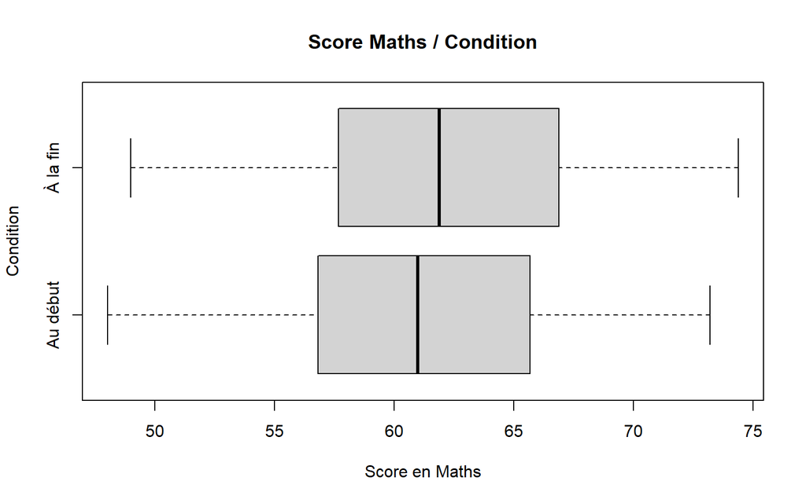

Figure 13.25: Distribution de deux groupes corrélés

```r
boxplot(x1,y1,
        main="Score Maths / Condition",
        xlab="Score en Maths",
        ylab="Condition",
        horizontal=TRUE,
        names=c("Au début","À la fin"))
```

On y note une différence entre les moyennes observées. La question est de savoir si cette différence est un reflet d’une différence réelle au niveau de la population.